# compareGroups 4.0: Descriptives by groups

Isaac Subirana, Joan Vila and Héctor Sanz

2019-09-19

**News**

- `tibble` class data sets possibly imported by `haven`, `readxl`, `readr`, etc. or to be used by `tydiverse` and `dplyr` packages are supported.
- new function called `descrTable` has been implemented to build descriptive tables in a single step.
- `export2md` to export descriptive tables to R-markdown documents has been improved and now supports stratified tables for HTML.
- new funciton called `strataTable` has been implemented to build descriptive tables by stratas (values or levels of a variable).
- Date variables are treated as continuous-non normal, performing medians, quartiles and non-parametric tests, but now are printed dates.
- New argument `var.equal` added in `compareGroups` and `descrTable`. This allows to consider different variances when comparing means between more than two groups.

# 1 Introduction

The **`compareGroups`** package (Subirana, Sanz, and Vila 2014) allows users to create tables displaying results of univariate analyses, stratified or not by categorical variable groupings.

Tables can easily be exported to CSV, LaTeX, HTML, PDF, Word or Excel, or inserted in R-markdown files to generate reports automatically.

This package can be used from the **`R`** prompt or from a user-friendly graphical user interface for non-R familiarized users.

The **`compareGroups`** package is available on CRAN repository. To load the package using the **`R`** prompt, enter:

```r
library(compareGroups)
```

This document provides an overview of the usage of the **`compareGroups`** package with a real examples, both using the R syntax and the graphical user interface. It is structure as follows:

- Introduction of the package (section 2) and the data used as example (section 3),
- Instructions to perform descriptive tables and exploration plots using R syntax are explained (section 4), and
- Usage of graphical user interface based on tcl-tk (section 5) and based on Shiny (section 6) are shown.

# 2 Package structure: classes and methods

The **`compareGroups`** package has three functions:

- `compareGroups` creates an object of class `compareGroups`. This object can be:
  - printed
  - summarized
  - plotted
  - updated
- `createTable` creates an object of class `createTable`. This object can be:
  - printed
  - summarized
- `export2csv`, `export2html`, `export2latex`, `export2pdf`, `export2md`, `export2word` and `export2xls` will export results to CSV, HTML, LaTeX, PDF, Markdown, Word or Excel, respectively.

Figure 1 shows how the package is structured in terms of functions, classes and methods.

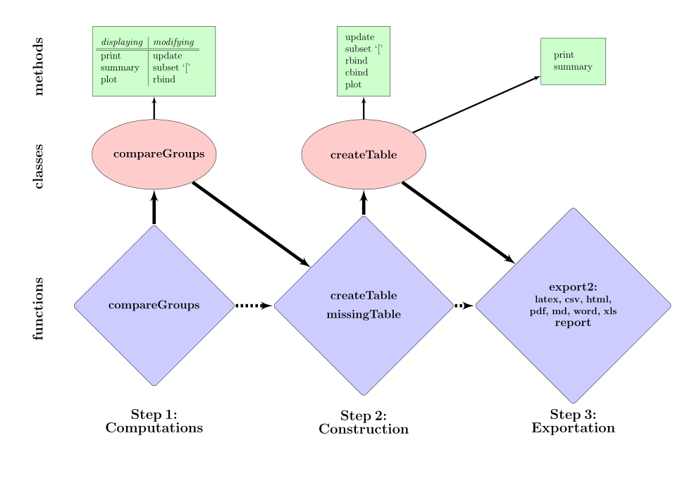

Figure 1. Diagram of package structure.

Since version 4.0, a new function called **`descrTable`** has been implemented which is a shortcut of `compareGroups`and `createTable`, i.e. step 1 and step 2 in a single step (see section 4.2.5).

# 3 Data used as example

To illustrate how this package works we sampled 85% data from the participants in [the PREDIMED study](http://www.predimed.es/) (Estruch et al. 2013). PREDIMED is a multicenter trial in Spain, were randomly assigned participants who were at high cardiovascular risk, but with no cardiovascular disease at enrolment, to one of three diets: a Mediterranean diet supplemented with extra-virgin olive oil (MedDiet+VOO), a Mediterranean diet supplemented with mixed nuts (MedDiet+Nuts), or a control diet (advice to reduce dietary fat). Participants received quarterly individual and group educational sessions and, depending on group assignment, free provision of extra-virgin olive oil, mixed nuts, or small non-food gifts. The primary end point was the rate of major cardiovascular events (myocardial infarction, stroke, or death from cardiovascular causes.

First of all, load PREDIMED data typing:

```r
data(predimed)
```

Variables and labels in this data frame are:

| Name | Label | Codes |
| --- | --- | --- |
| group | Intervention group | Control; MedDiet + Nuts; MedDiet + VOO |
| sex | Sex | Male; Female |
| age | Age |  |
| smoke | Smoking | Never; Current; Former |
| bmi | Body mass index |  |
| waist | Waist circumference |  |
| wth | Waist-to-height ratio |  |
| htn | Hypertension | No; Yes |
| diab | Type-2 diabetes | No; Yes |
| hyperchol | Dyslipidemia | No; Yes |
| famhist | Family history of premature CHD | No; Yes |
| hormo | Hormone-replacement therapy | No; Yes |
| p14 | MeDiet Adherence score |  |
| toevent | follow-up to main event (years) |  |
| event | AMI, stroke, or CV Death | No; Yes |

OBSERVATIONS:

1. It is important to note that **`compareGroups`** is not aimed to perform quality control of the data. Other useful packages such as **`2lh`** (Genolini, Desgraupes, and Franca 2011) are available for this purpose.
2. It is strongly recommended that the *data.frame* contain only the variables to be analyzed; the ones not needed in the present analysis should be removed from the list.
3. The nature of variables to be analyzed should be known, or at least which variables are to be used as categorical. It is important to code categorical variables as factors and the order of their levels is meaningful in this package.
4. To label the variables set the “label” attributes from each of them. The tables of results will contain the variable labels (by default).

## 3.1 Time-to-event variables

A variable of class `Surv` must be created to deal with time-to-event variables (i.e., time to Cardiovascular event/censored in our example):

```r
predimed$tmain <- with(predimed, Surv(toevent, event == "Yes"))
attr(predimed$tmain, "label") <- "AMI, stroke, or CV Death"
```

# 4 Using syntax

## 4.1 Computing descriptives

`compareGroups` is the main function which does all the calculus. It is needed to store results in an object. Later, applying the function `createTable` (Section 4.2) to this object will create tables of the analysis results.

For example, to perform a univariate analysis with the *predimed* data between *group* (“response” variable) and all other variables (“explanatory” variables), this formula is required:

```r
compareGroups(group ~ ., data = predimed)
```

### 4.1.1 Selecting response variables

If only a dot occurs on the right side of the `~` all variables in the data frame will be used.

To remove the variable *toevent* and *event* from the analysis:

```r
compareGroups(group ~ . - toevent - event, data = predimed)
```

To select some explanatory variables (e.g., *age*, *sex* and *waist*) and store results in an object of class `compareGroups`:

```r
res <- compareGroups(group ~ age + sex + smoke + waist + hormo,
    data = predimed)
res
```

```
-------- Summary of results by groups of 'Intervention group'---------


  var                         N    p.value  method            selection
1 Age                         6324 0.003**  continuous normal ALL
2 Sex                         6324 <0.001** categorical       ALL
3 Smoking                     6324 0.444    categorical       ALL
4 Waist circumference         6324 0.045**  continuous normal ALL
5 Hormone-replacement therapy 5661 0.850    categorical       ALL
-----
Signif. codes:  0 '**' 0.05 '*' 0.1 ' ' 1
```

Note: Although we have full data (n= 6324) for Age, Sex and Waist circumference, there are some missing data in Hormone-replacement therapy (probably male participants).

Age & Waist circumference has been used as continuous and normal distributed. Sex, Smoking & Hormone-replacement therapy as categorical.

No filters have been used (e.g., selecting only treated patients); therefore, the *selection* column lists “ALL” (for all variables).

### 4.1.2 Subsetting

To perform the analysis in a subset of participants (e.g., “female” participants):

```r
compareGroups(group ~ age + smoke + waist + hormo, data = predimed,
    subset = sex == "Female")
```

```
-------- Summary of results by groups of 'group'---------


  var                         N    p.value method            selection
1 Age                         3645 0.056*  continuous normal sex == "Female"
2 Smoking                     3645 0.907   categorical       sex == "Female"
3 Waist circumference         3645 0.016** continuous normal sex == "Female"
4 Hormone-replacement therapy 3459 0.898   categorical       sex == "Female"
-----
Signif. codes:  0 '**' 0.05 '*' 0.1 ' ' 1
```

Note that only results for female participants are shown.

To subset specific variable/s (e.g., *hormo* and *waist*):

```r
compareGroups(group ~ age + sex + smoke + waist + hormo, data = predimed,
    selec = list(hormo = sex == "Female", waist = waist > 20))
```

```
-------- Summary of results by groups of 'Intervention group'---------


  var                         N    p.value  method            selection
1 Age                         6324 0.003**  continuous normal ALL
2 Sex                         6324 <0.001** categorical       ALL
3 Smoking                     6324 0.444    categorical       ALL
4 Waist circumference         6324 0.045**  continuous normal waist > 20
5 Hormone-replacement therapy 3459 0.898    categorical       sex == "Female"
-----
Signif. codes:  0 '**' 0.05 '*' 0.1 ' ' 1
```

Combinations are also allowed, e.g.:

```r
compareGroups(group ~ age + smoke + waist + hormo, data = predimed,
    selec = list(waist = !is.na(hormo)), subset = sex == "Female")
```

```
-------- Summary of results by groups of 'group'---------


  var                         N    p.value method            selection
1 Age                         3645 0.056*  continuous normal sex == "Female"
2 Smoking                     3645 0.907   categorical       sex == "Female"
3 Waist circumference         3459 0.007** continuous normal (sex == "Female") & (!is.na(hormo))
4 Hormone-replacement therapy 3459 0.898   categorical       sex == "Female"
-----
Signif. codes:  0 '**' 0.05 '*' 0.1 ' ' 1
```

A variable can appear twice in the formula, e.g.:

```r
compareGroups(group ~ age + sex + bmi + bmi + waist + hormo,
    data = predimed, selec = list(bmi.1 = !is.na(hormo)))
```

```
-------- Summary of results by groups of 'Intervention group'---------


  var                         N    p.value  method            selection
1 Age                         6324 0.003**  continuous normal ALL
2 Sex                         6324 <0.001** categorical       ALL
3 Body mass index             6324 <0.001** continuous normal ALL
4 Body mass index             5661 <0.001** continuous normal !is.na(hormo)
5 Waist circumference         6324 0.045**  continuous normal ALL
6 Hormone-replacement therapy 5661 0.850    categorical       ALL
-----
Signif. codes:  0 '**' 0.05 '*' 0.1 ' ' 1
```

In this case results for *bmi* will be reported for all participants (n= 6324) and also for only those with no missing in Hormone-replacement therapy (!is.na(hormo)). Note that “bmi.1” in the `selec` argument refers to the second time that *bmi* appears in the formula.

### 4.1.3 Methods for continuous variables

By default continuous variables are analyzed as normal-distributed. When a table is built (see `createTable` function, Section 4.2), continuous variables will be described with mean and standard deviation. To change default options, e.g., “waist” used as non-normal distributed:

```r
compareGroups(group ~ age + smoke + waist + hormo, data = predimed,
    method = c(waist = 2))
```

```
-------- Summary of results by groups of 'Intervention group'---------


  var                         N    p.value method                selection
1 Age                         6324 0.003** continuous normal     ALL
2 Smoking                     6324 0.444   categorical           ALL
3 Waist circumference         6324 0.085*  continuous non-normal ALL
4 Hormone-replacement therapy 5661 0.850   categorical           ALL
-----
Signif. codes:  0 '**' 0.05 '*' 0.1 ' ' 1
```

Possible values in methods statement are:

- 1: forces analysis as normal-distributed
- 2: forces analysis as continuous non-normal
- 3: forces analysis as categorical
- NA: performs a Shapiro-Wilks test to decide between normal or non-normal

If the `method` argument is stated as `NA` for a variable, then a Shapiro-Wilk test for normality is used to decide if the variable is normal or non-normal distributed. To change the significance threshold:

```r
compareGroups(group ~ age + smoke + waist + hormo, data = predimed,
    method = c(waist = NA), alpha = 0.01)
```

```
-------- Summary of results by groups of 'Intervention group'---------


  var                         N    p.value method                selection
1 Age                         6324 0.003** continuous normal     ALL
2 Smoking                     6324 0.444   categorical           ALL
3 Waist circumference         6324 0.085*  continuous non-normal ALL
4 Hormone-replacement therapy 5661 0.850   categorical           ALL
-----
Signif. codes:  0 '**' 0.05 '*' 0.1 ' ' 1
```

All non factor variables are considered as continuous. Exception is made (by default) for those that have fewer than 5 different values. This threshold can be changed in the **min.dis** statement:

```r
predimed$age7gr <- as.integer(cut(predimed$age, breaks = c(-Inf,
    55, 60, 65, 70, 75, 80, Inf), right = TRUE))
compareGroups(group ~ age7gr, data = predimed, method = c(age7gr = NA))
```

```
-------- Summary of results by groups of 'Intervention group'---------


  var    N    p.value method                selection
1 age7gr 6324 0.007** continuous non-normal ALL
-----
Signif. codes:  0 '**' 0.05 '*' 0.1 ' ' 1
```

```r
compareGroups(group ~ age7gr, data = predimed, method = c(age7gr = NA),
    min.dis = 8)
```

```
-------- Summary of results by groups of 'Intervention group'---------


  var    N    p.value method      selection
1 age7gr 6324 0.009** categorical ALL
-----
Signif. codes:  0 '**' 0.05 '*' 0.1 ' ' 1
```

To avoid errors the maximum categories for the response variable is set at 5 in this example (default value). If this variable has more than 5 different values, the function `compareGroups` returns an error message. For example:

```r
compareGroups(age7gr ~ sex + bmi + waist, data = predimed)
```

```
Error en compareGroups.default(X = X, y = y, include.label = include.label,  :
number of groups must be less or equal to 5
```

Defaults setting can be changed with the **max.ylev** statement:

```r
compareGroups(age7gr ~ sex + bmi + waist, data = predimed, max.ylev = 7)
```

```
-------- Summary of results by groups of 'age7gr'---------


  var                 N    p.value  method            selection
1 Sex                 6324 <0.001** categorical       ALL
2 Body mass index     6324 0.021**  continuous normal ALL
3 Waist circumference 6324 0.034**  continuous normal ALL
-----
Signif. codes:  0 '**' 0.05 '*' 0.1 ' ' 1
```

Similarly, by default there is a limit for the maximum number of levels for an explanatory variable. If this level is exceeded, the variable is removed from the analysis and a warning message is printed:

```r
compareGroups(group ~ sex + age7gr, method = (age7gr = 3), data = predimed,
    max.xlev = 5)
```

```
Warning in compareGroups.default(X = X, y = y, include.label = include.label,  :
Variables 'age7gr' have been removed since some errors ocurred
```

### 4.1.4 Dressing up the output

Although the options described in this section correspond to `compareGroups` function, results of changing/setting them won’t be visible until the table is created with the `createTable` function (explained later).

- **`include.label`:** By default the variable labels are shown in the output (if there is no label the name will be printed). Changing the statement include.label from “= TRUE” (default) to “= FALSE” will cause variable names to be printed instead.

```r
compareGroups(group ~ age + smoke + waist + hormo, data = predimed,
    include.label = FALSE)
```

```
-------- Summary of results by groups of 'group'---------


  var   N    p.value method            selection
1 age   6324 0.003** continuous normal ALL
2 smoke 6324 0.444   categorical       ALL
3 waist 6324 0.045** continuous normal ALL
4 hormo 5661 0.850   categorical       ALL
-----
Signif. codes:  0 '**' 0.05 '*' 0.1 ' ' 1
```

- **`Q1`, `Q3`:** When the method for a variable is stated as “2” (i.e., to be analyzed as continuous non-normal; see section 4.1.3), by default the median and quartiles 1 and 3 will be shown in the final results, after applying the function `createTable` (see Section 4.2).

```r
resu1 <- compareGroups(group ~ age + waist, data = predimed,
    method = c(waist = 2))
createTable(resu1)
```

```
--------Summary descriptives table by 'Intervention group'---------

__________________________________________________________________________
                       Control     MedDiet + Nuts MedDiet + VOO  p.overall
                        N=2042         N=2100         N=2182
¯¯¯¯¯¯¯¯¯¯¯¯¯¯¯¯¯¯¯¯¯¯¯¯¯¯¯¯¯¯¯¯¯¯¯¯¯¯¯¯¯¯¯¯¯¯¯¯¯¯¯¯¯¯¯¯¯¯¯¯¯¯¯¯¯¯¯¯¯¯¯¯¯¯
Age                  67.3 (6.28)    66.7 (6.02)    67.0 (6.21)     0.003
Waist circumference 101 [94.0;108] 100 [93.0;107] 100 [93.0;107]   0.085
¯¯¯¯¯¯¯¯¯¯¯¯¯¯¯¯¯¯¯¯¯¯¯¯¯¯¯¯¯¯¯¯¯¯¯¯¯¯¯¯¯¯¯¯¯¯¯¯¯¯¯¯¯¯¯¯¯¯¯¯¯¯¯¯¯¯¯¯¯¯¯¯¯¯
```

Note: percentiles 25 and 75 are calculated for “Waist circumference”.

To get instead percentile 2.5% and 97.5%:

```r
resu2 <- compareGroups(group ~ age + smoke + waist + hormo, data = predimed,
    method = c(waist = 2), Q1 = 0.025, Q3 = 0.975)
createTable(resu2)
```

```
--------Summary descriptives table by 'Intervention group'---------

___________________________________________________________________________________
                                Control     MedDiet + Nuts MedDiet + VOO  p.overall
                                 N=2042         N=2100         N=2182
¯¯¯¯¯¯¯¯¯¯¯¯¯¯¯¯¯¯¯¯¯¯¯¯¯¯¯¯¯¯¯¯¯¯¯¯¯¯¯¯¯¯¯¯¯¯¯¯¯¯¯¯¯¯¯¯¯¯¯¯¯¯¯¯¯¯¯¯¯¯¯¯¯¯¯¯¯¯¯¯¯¯¯
Age                           67.3 (6.28)    66.7 (6.02)    67.0 (6.21)     0.003
Smoking:                                                                    0.444
    Never                     1282 (62.8%)   1259 (60.0%)   1351 (61.9%)
    Current                   270 (13.2%)    296 (14.1%)    292 (13.4%)
    Former                    490 (24.0%)    545 (26.0%)    539 (24.7%)
Waist circumference          101 [80.0;123] 100 [80.0;121] 100 [80.0;121]   0.085
Hormone-replacement therapy:                                                0.850
    No                        1811 (98.3%)   1835 (98.4%)   1918 (98.2%)
    Yes                        31 (1.68%)     30 (1.61%)     36 (1.84%)
¯¯¯¯¯¯¯¯¯¯¯¯¯¯¯¯¯¯¯¯¯¯¯¯¯¯¯¯¯¯¯¯¯¯¯¯¯¯¯¯¯¯¯¯¯¯¯¯¯¯¯¯¯¯¯¯¯¯¯¯¯¯¯¯¯¯¯¯¯¯¯¯¯¯¯¯¯¯¯¯¯¯¯
```

To get minimum and maximum:

```r
compareGroups(group ~ age + smoke + waist + hormo, data = predimed,
    method = c(waist = 2), Q1 = 0, Q3 = 1)
```

- **`simplify`:** Sometimes a categorical variable has no individuals for a specific group. For example, *smoker* has 3 levels. As an example and to illustrate this problem, we have created a new variable *smk* with a new category (“Unknown”):

```r
predimed$smk <- predimed$smoke
levels(predimed$smk) <- c("Never smoker", "Current or former < 1y",
    "Never or former >= 1y", "Unknown")
attr(predimed$smk, "label") <- "Smoking 4 cat."
cbind(table(predimed$smk))
```

```
                       [,1]
Never smoker           3892
Current or former < 1y  858
Never or former >= 1y  1574
Unknown                   0
```

Note that this new category (“unknown”) has no individuals:

```r
compareGroups(group ~ age + smk + waist + hormo, data = predimed)
```

[output not shown]

Note that a “Warning” message is printed related to the problem with *smk*.

To avoid using empty categories, `simplify` must be stated as `TRUE` (Default value).

```r
compareGroups(group ~ age + smk, data = predimed, simplify = FALSE)
```

[output not shown]

Nota that a “warning” message is shown and no p-values are calculated for “Smoking”.

### 4.1.5 Summary

```r
res <- compareGroups(group ~ age + sex + smoke + waist + hormo,
    method = c(waist = 2), data = predimed)
summary(res[c(1, 2, 4)])
```

```
 --- Descriptives of each row-variable by groups of 'Intervention group' ---

-------------------
row-variable: Age

               N    mean     sd       lower    upper    p.overall p.trend  p.Control vs MedDiet + Nuts p.Control vs MedDiet + VOO
[ALL]          6324 67.0117  6.17499  66.85948 67.16392
Control        2042 67.34231 6.27992  67.06977 67.61485 0.002666  0.101163 0.001672                    0.20596
MedDiet + Nuts 2100 66.6819  6.016395 66.42444 66.93937
MedDiet + VOO  2182 67.01971 6.212578 66.75889 67.28052
               p.MedDiet + Nuts vs MedDiet + VOO
[ALL]
Control        0.172672
MedDiet + Nuts
MedDiet + VOO

-------------------
row-variable: Sex

               Male Female Male (row%) Female (row%) p.overall p.trend  p.Control vs MedDiet + Nuts p.Control vs MedDiet + VOO
[ALL]          2679 3645   42.36243    57.63757
Control        812  1230   39.76494    60.23506      8.1e-05   0.388386 0.000133                    0.358324
MedDiet + Nuts 968  1132   46.09524    53.90476
MedDiet + VOO  899  1283   41.20073    58.79927
               p.MedDiet + Nuts vs MedDiet + VOO
[ALL]
Control        0.002076
MedDiet + Nuts
MedDiet + VOO

-------------------
row-variable: Waist circumference

               N    med Q1 Q3  lower upper p.overall p.trend  p.Control vs MedDiet + Nuts p.Control vs MedDiet + VOO
[ALL]          6324 100 93 107 100   101
Control        2042 101 94 108 100   101   0.084601  0.039557 0.125792                    0.110639
MedDiet + Nuts 2100 100 93 107 100   101
MedDiet + VOO  2182 100 93 107 100   101
               p.MedDiet + Nuts vs MedDiet + VOO
[ALL]
Control        0.743479
MedDiet + Nuts
MedDiet + VOO
```

### 4.1.6 Plotting

Variables can be plotted to see their distribution. Plots differ according to whether the variable is continuous or categorical. Plots can be seen on-screen or saved in different formats (BMP, JPG’, PNG, TIF or PDF). To specify the format use the argument `type’.

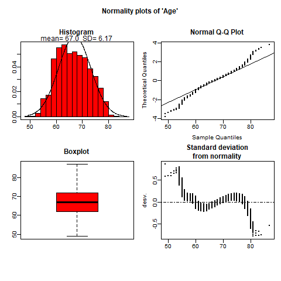

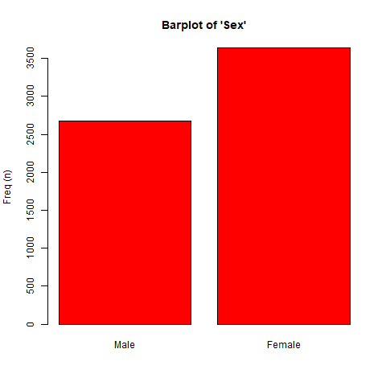

```r
plot(res[c(1, 2)], file = "./figures/univar/", type = "png")
```

Plots also can be done according to grouping variable. In this case only a boxplot is shown for continuous variables:

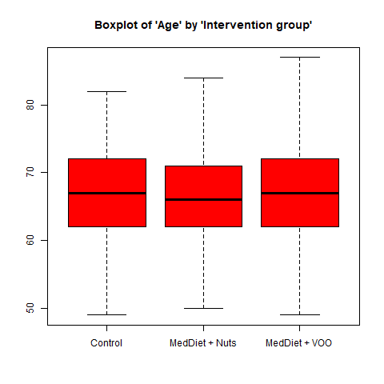

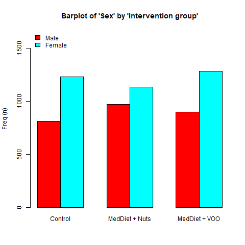

```r
plot(res[c(1, 2)], bivar = TRUE, file = "./figures/bivar/", type = "png")
```

### 4.1.7 Updating

The object from `compareGroups` can later be updated. For example:

```r
res <- compareGroups(group ~ age + sex + smoke + waist + hormo,
    data = predimed)
res
```

```
-------- Summary of results by groups of 'Intervention group'---------


  var                         N    p.value  method            selection
1 Age                         6324 0.003**  continuous normal ALL
2 Sex                         6324 <0.001** categorical       ALL
3 Smoking                     6324 0.444    categorical       ALL
4 Waist circumference         6324 0.045**  continuous normal ALL
5 Hormone-replacement therapy 5661 0.850    categorical       ALL
-----
Signif. codes:  0 '**' 0.05 '*' 0.1 ' ' 1
```

The object `res` is updated using:

```r
res <- update(res, . ~ . - sex + bmi + toevent, subset = sex ==
    "Female", method = c(waist = 2, tovent = 2), selec = list(bmi = !is.na(hormo)))
res
```

[output not shown]

Note that “Sex” is removed as an explanatory variable but used as a filter, subsetting only “Female” participants. Variable “Waist circumference” has been changed to “continuous non-normal”. Two new variables have been added: Body mass index and Follow-up (stated continuous non-normal). For Body mass index is stated to show only data of participants with non-missing values in Hormone-replacement therapy.

### 4.1.8 Substracting results

Since version 3.0, there is a new function called `getResults` to retrieve some specific results computed by `compareGroups`, such as p-values, descriptives (means, proportions, …), etc.

For example, it may be interesting to recover the p-values for each variable as a vector to further manipulate it in **`R`**, like adjusting for multiple comparison with `p.adjust`. For example, lets take the example data from **`SNPassoc`** package that contains information of dozens of SNPs (genetic variants) from a sample of cases and controls. In this case we analize five of them:

```r
library(SNPassoc)
data(SNPs)
tab <- createTable(compareGroups(casco ~ snp10001 + snp10002 +
    snp10005 + snp10008 + snp10009, SNPs))
pvals <- getResults(tab, "p.overall")
p.adjust(pvals, method = "BH")
```

```
 snp10001  snp10002  snp10005  snp10008  snp10009
0.7051300 0.7072158 0.7583432 0.7583432 0.7072158
```

### 4.1.9 Odds Ratios and Hazard Ratios

When the response variable is binary, the Odds Ratio (OR) can be printed in the final table. If the response variable is time-to-event (see Section 3.1), the Hazard Ratio (HR) can be printed instead.

- **`ref`:** This statement can be used to change the reference category:

```r
res1 <- compareGroups(htn ~ age + sex + bmi + smoke, data = predimed,
    ref = 1)
createTable(res1, show.ratio = TRUE)
```

```
--------Summary descriptives table by 'Hypertension'---------

___________________________________________________________________________
                    No          Yes             OR        p.ratio p.overall
                  N=1089       N=5235
¯¯¯¯¯¯¯¯¯¯¯¯¯¯¯¯¯¯¯¯¯¯¯¯¯¯¯¯¯¯¯¯¯¯¯¯¯¯¯¯¯¯¯¯¯¯¯¯¯¯¯¯¯¯¯¯¯¯¯¯¯¯¯¯¯¯¯¯¯¯¯¯¯¯¯
Age             65.9 (6.19) 67.2 (6.15)  1.04 [1.03;1.05] <0.001   <0.001
Sex:                                                               <0.001
    Male        595 (54.6%) 2084 (39.8%)       Ref.        Ref.
    Female      494 (45.4%) 3151 (60.2%) 1.82 [1.60;2.08]  0.000
Body mass index 28.9 (3.69) 30.2 (3.80)  1.10 [1.08;1.12] <0.001   <0.001
Smoking:                                                           <0.001
    Never       536 (49.2%) 3356 (64.1%)       Ref.        Ref.
    Current     233 (21.4%) 625 (11.9%)  0.43 [0.36;0.51]  0.000
    Former      320 (29.4%) 1254 (24.0%) 0.63 [0.54;0.73] <0.001
¯¯¯¯¯¯¯¯¯¯¯¯¯¯¯¯¯¯¯¯¯¯¯¯¯¯¯¯¯¯¯¯¯¯¯¯¯¯¯¯¯¯¯¯¯¯¯¯¯¯¯¯¯¯¯¯¯¯¯¯¯¯¯¯¯¯¯¯¯¯¯¯¯¯¯
```

Note that for categorical response variables the reference category is the first one in the statement:

```r
res2 <- compareGroups(htn ~ age + sex + bmi + smoke, data = predimed,
    ref = c(smoke = 1, sex = 2))
createTable(res2, show.ratio = TRUE)
```

```
--------Summary descriptives table by 'Hypertension'---------

___________________________________________________________________________
                    No          Yes             OR        p.ratio p.overall
                  N=1089       N=5235
¯¯¯¯¯¯¯¯¯¯¯¯¯¯¯¯¯¯¯¯¯¯¯¯¯¯¯¯¯¯¯¯¯¯¯¯¯¯¯¯¯¯¯¯¯¯¯¯¯¯¯¯¯¯¯¯¯¯¯¯¯¯¯¯¯¯¯¯¯¯¯¯¯¯¯
Age             65.9 (6.19) 67.2 (6.15)  1.04 [1.03;1.05] <0.001   <0.001
Sex:                                                               <0.001
    Male        595 (54.6%) 2084 (39.8%) 0.55 [0.48;0.63]  0.000
    Female      494 (45.4%) 3151 (60.2%)       Ref.        Ref.
Body mass index 28.9 (3.69) 30.2 (3.80)  1.10 [1.08;1.12] <0.001   <0.001
Smoking:                                                           <0.001
    Never       536 (49.2%) 3356 (64.1%)       Ref.        Ref.
    Current     233 (21.4%) 625 (11.9%)  0.43 [0.36;0.51]  0.000
    Former      320 (29.4%) 1254 (24.0%) 0.63 [0.54;0.73] <0.001
¯¯¯¯¯¯¯¯¯¯¯¯¯¯¯¯¯¯¯¯¯¯¯¯¯¯¯¯¯¯¯¯¯¯¯¯¯¯¯¯¯¯¯¯¯¯¯¯¯¯¯¯¯¯¯¯¯¯¯¯¯¯¯¯¯¯¯¯¯¯¯¯¯¯¯
```

Note that the reference category for Smoking status is the first and for Sex the second.

- **`ref.no`:** Similarly to the `ref` statement, `ref.no` is used to state “no” as the reference category for all variables with this category:

```r
res <- compareGroups(htn ~ age + sex + bmi + hormo + hyperchol,
    data = predimed, ref.no = "NO")
createTable(res, show.ratio = TRUE)
```

```
--------Summary descriptives table by 'Hypertension'---------

________________________________________________________________________________________
                                 No          Yes             OR        p.ratio p.overall
                               N=1089       N=5235
¯¯¯¯¯¯¯¯¯¯¯¯¯¯¯¯¯¯¯¯¯¯¯¯¯¯¯¯¯¯¯¯¯¯¯¯¯¯¯¯¯¯¯¯¯¯¯¯¯¯¯¯¯¯¯¯¯¯¯¯¯¯¯¯¯¯¯¯¯¯¯¯¯¯¯¯¯¯¯¯¯¯¯¯¯¯¯¯
Age                          65.9 (6.19) 67.2 (6.15)  1.04 [1.03;1.05] <0.001   <0.001
Sex:                                                                            <0.001
    Male                     595 (54.6%) 2084 (39.8%)       Ref.        Ref.
    Female                   494 (45.4%) 3151 (60.2%) 1.82 [1.60;2.08]  0.000
Body mass index              28.9 (3.69) 30.2 (3.80)  1.10 [1.08;1.12] <0.001   <0.001
Hormone-replacement therapy:                                                     0.856
    No                       928 (98.4%) 4636 (98.3%)       Ref.        Ref.
    Yes                      15 (1.59%)   82 (1.74%)  1.08 [0.64;1.97]  0.773
Dyslipidemia:                                                                   <0.001
    No                       409 (37.6%) 1337 (25.5%)       Ref.        Ref.
    Yes                      680 (62.4%) 3898 (74.5%) 1.75 [1.53;2.01] <0.001
¯¯¯¯¯¯¯¯¯¯¯¯¯¯¯¯¯¯¯¯¯¯¯¯¯¯¯¯¯¯¯¯¯¯¯¯¯¯¯¯¯¯¯¯¯¯¯¯¯¯¯¯¯¯¯¯¯¯¯¯¯¯¯¯¯¯¯¯¯¯¯¯¯¯¯¯¯¯¯¯¯¯¯¯¯¯¯¯
```

Note: “no”, “No” or “NO” will produce the same results; the coding is not case sensitive.

- **`fact.ratio`**: By default OR or HR for continuous variables are calculated for each unit increase. It can be changed by the `fact.or` statement:

```r
res <- compareGroups(htn ~ age + bmi, data = predimed)
createTable(res, show.ratio = TRUE)
```

```
--------Summary descriptives table by 'Hypertension'---------

__________________________________________________________________________
                    No          Yes            OR        p.ratio p.overall
                  N=1089      N=5235
¯¯¯¯¯¯¯¯¯¯¯¯¯¯¯¯¯¯¯¯¯¯¯¯¯¯¯¯¯¯¯¯¯¯¯¯¯¯¯¯¯¯¯¯¯¯¯¯¯¯¯¯¯¯¯¯¯¯¯¯¯¯¯¯¯¯¯¯¯¯¯¯¯¯
Age             65.9 (6.19) 67.2 (6.15) 1.04 [1.03;1.05] <0.001   <0.001
Body mass index 28.9 (3.69) 30.2 (3.80) 1.10 [1.08;1.12] <0.001   <0.001
¯¯¯¯¯¯¯¯¯¯¯¯¯¯¯¯¯¯¯¯¯¯¯¯¯¯¯¯¯¯¯¯¯¯¯¯¯¯¯¯¯¯¯¯¯¯¯¯¯¯¯¯¯¯¯¯¯¯¯¯¯¯¯¯¯¯¯¯¯¯¯¯¯¯
```

```r
res <- compareGroups(htn ~ age + bmi, data = predimed, fact.ratio = c(age = 10,
    bmi = 2))
createTable(res, show.ratio = TRUE)
```

```
--------Summary descriptives table by 'Hypertension'---------

__________________________________________________________________________
                    No          Yes            OR        p.ratio p.overall
                  N=1089      N=5235
¯¯¯¯¯¯¯¯¯¯¯¯¯¯¯¯¯¯¯¯¯¯¯¯¯¯¯¯¯¯¯¯¯¯¯¯¯¯¯¯¯¯¯¯¯¯¯¯¯¯¯¯¯¯¯¯¯¯¯¯¯¯¯¯¯¯¯¯¯¯¯¯¯¯
Age             65.9 (6.19) 67.2 (6.15) 1.43 [1.28;1.59] <0.001   <0.001
Body mass index 28.9 (3.69) 30.2 (3.80) 1.22 [1.17;1.26] <0.001   <0.001
¯¯¯¯¯¯¯¯¯¯¯¯¯¯¯¯¯¯¯¯¯¯¯¯¯¯¯¯¯¯¯¯¯¯¯¯¯¯¯¯¯¯¯¯¯¯¯¯¯¯¯¯¯¯¯¯¯¯¯¯¯¯¯¯¯¯¯¯¯¯¯¯¯¯
```

Here the OR is for the increase of 10 years for Age and 2 units for “Body mass index”.

- **`ref.y`:** By default when OR or HR are calculated, the reference category for the response variable is the first. The reference category could be changed using the `ref.y` statement:

```r
res <- compareGroups(htn ~ age + sex + bmi + hyperchol, data = predimed)
createTable(res, show.ratio = TRUE)
```

```
--------Summary descriptives table by 'Hypertension'---------

___________________________________________________________________________
                    No          Yes             OR        p.ratio p.overall
                  N=1089       N=5235
¯¯¯¯¯¯¯¯¯¯¯¯¯¯¯¯¯¯¯¯¯¯¯¯¯¯¯¯¯¯¯¯¯¯¯¯¯¯¯¯¯¯¯¯¯¯¯¯¯¯¯¯¯¯¯¯¯¯¯¯¯¯¯¯¯¯¯¯¯¯¯¯¯¯¯
Age             65.9 (6.19) 67.2 (6.15)  1.04 [1.03;1.05] <0.001   <0.001
Sex:                                                               <0.001
    Male        595 (54.6%) 2084 (39.8%)       Ref.        Ref.
    Female      494 (45.4%) 3151 (60.2%) 1.82 [1.60;2.08]  0.000
Body mass index 28.9 (3.69) 30.2 (3.80)  1.10 [1.08;1.12] <0.001   <0.001
Dyslipidemia:                                                      <0.001
    No          409 (37.6%) 1337 (25.5%)       Ref.        Ref.
    Yes         680 (62.4%) 3898 (74.5%) 1.75 [1.53;2.01] <0.001
¯¯¯¯¯¯¯¯¯¯¯¯¯¯¯¯¯¯¯¯¯¯¯¯¯¯¯¯¯¯¯¯¯¯¯¯¯¯¯¯¯¯¯¯¯¯¯¯¯¯¯¯¯¯¯¯¯¯¯¯¯¯¯¯¯¯¯¯¯¯¯¯¯¯¯
```

Note: This output shows the OR of having hypertension. Therefore, “Non-hypertension” is the reference category.

```r
res <- compareGroups(htn ~ age + sex + bmi + hyperchol, data = predimed,
    ref.y = 2)
createTable(res, show.ratio = TRUE)
```

```
--------Summary descriptives table by 'Hypertension'---------

___________________________________________________________________________
                    No          Yes             OR        p.ratio p.overall
                  N=1089       N=5235
¯¯¯¯¯¯¯¯¯¯¯¯¯¯¯¯¯¯¯¯¯¯¯¯¯¯¯¯¯¯¯¯¯¯¯¯¯¯¯¯¯¯¯¯¯¯¯¯¯¯¯¯¯¯¯¯¯¯¯¯¯¯¯¯¯¯¯¯¯¯¯¯¯¯¯
Age             65.9 (6.19) 67.2 (6.15)  0.96 [0.98;0.95] <0.001   <0.001
Sex:                                                               <0.001
    Male        595 (54.6%) 2084 (39.8%)       Ref.        Ref.
    Female      494 (45.4%) 3151 (60.2%) 0.55 [0.48;0.63]  0.000
Body mass index 28.9 (3.69) 30.2 (3.80)  0.91 [0.92;0.89] <0.001   <0.001
Dyslipidemia:                                                      <0.001
    No          409 (37.6%) 1337 (25.5%)       Ref.        Ref.
    Yes         680 (62.4%) 3898 (74.5%) 0.57 [0.50;0.65] <0.001
¯¯¯¯¯¯¯¯¯¯¯¯¯¯¯¯¯¯¯¯¯¯¯¯¯¯¯¯¯¯¯¯¯¯¯¯¯¯¯¯¯¯¯¯¯¯¯¯¯¯¯¯¯¯¯¯¯¯¯¯¯¯¯¯¯¯¯¯¯¯¯¯¯¯¯
```

Note: This output shows the OR of having No hypertension, and ‘Hypertension’ is now the reference category.

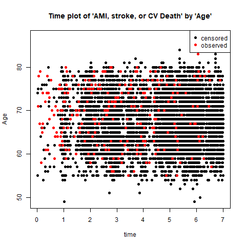

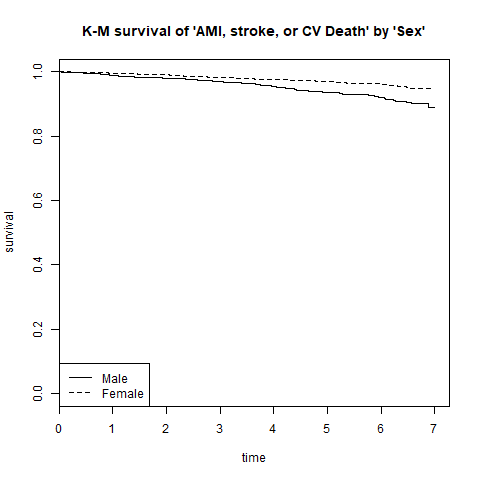

```r
plot(compareGroups(tmain ~ sex, data = predimed), bivar = TRUE,
    file = "./figures/bivarsurv/", type = "png")
plot(compareGroups(tmain ~ age, data = predimed), bivar = TRUE,
    file = "./figures/bivarsurv/", type = "png")
```

### 4.1.10 Time-to-event explanatory variables

When a variable of class `Surv` (see Section 3.1) is used as explanatory it will be described with the probability of event, computed by Kaplan-Meier, up to a stated time.

- **`timemax`:** By default probability is calculated at the median of the follow-up period. `timemax` option allows us to change at what time probability is calculated.

```r
res <- compareGroups(sex ~ age + tmain, timemax = c(tmain = 3),
    data = predimed)
res
```

[output not shown]

Note that `tmain` is calculated at 3 years (see section 3.1).

The `plot` function applied to a variable of class `Surv` returns a Kaplan-Meier figure. The figure can be stratified by the grouping variable.

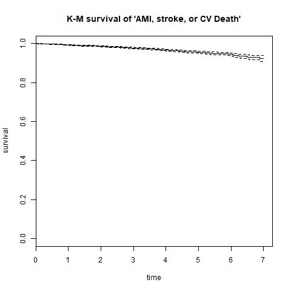

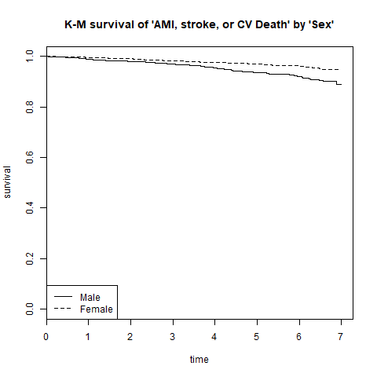

```r
plot(res[2], file = "./figures/univar/", type = "png")
plot(res[2], bivar = TRUE, file = "./figures/bivar/", type = "png")
```

## 4.2 Performing the descritive table

The `createTable` function, applied to an object of `compareGroups` class, returns tables with descriptives that can be displayed on-screen or exported to CSV, LaTeX, HTML, Word or Excel.

```r
res <- compareGroups(group ~ age + sex + smoke + waist + hormo,
    data = predimed, selec = list(hormo = sex == "Female"))
restab <- createTable(res)
```

Two tables are created with the `createTable` function: one with the descriptives and the other with the available data. The `print` method applied to an object of class `createTable` prints one or both tables on the **`R`** console:

```r
print(restab, which.table = "descr")
```

```
--------Summary descriptives table by 'Intervention group'---------

________________________________________________________________________________
                               Control    MedDiet + Nuts MedDiet + VOO p.overall
                                N=2042        N=2100        N=2182
¯¯¯¯¯¯¯¯¯¯¯¯¯¯¯¯¯¯¯¯¯¯¯¯¯¯¯¯¯¯¯¯¯¯¯¯¯¯¯¯¯¯¯¯¯¯¯¯¯¯¯¯¯¯¯¯¯¯¯¯¯¯¯¯¯¯¯¯¯¯¯¯¯¯¯¯¯¯¯¯
Age                          67.3 (6.28)   66.7 (6.02)    67.0 (6.21)    0.003
Sex:                                                                    <0.001
    Male                     812 (39.8%)   968 (46.1%)    899 (41.2%)
    Female                   1230 (60.2%)  1132 (53.9%)  1283 (58.8%)
Smoking:                                                                 0.444
    Never                    1282 (62.8%)  1259 (60.0%)  1351 (61.9%)
    Current                  270 (13.2%)   296 (14.1%)    292 (13.4%)
    Former                   490 (24.0%)   545 (26.0%)    539 (24.7%)
Waist circumference           101 (10.8)    100 (10.6)    100 (10.4)     0.045
Hormone-replacement therapy:                                             0.898
    No                       1143 (97.4%)  1036 (97.2%)  1183 (97.0%)
    Yes                       31 (2.64%)    30 (2.81%)    36 (2.95%)
¯¯¯¯¯¯¯¯¯¯¯¯¯¯¯¯¯¯¯¯¯¯¯¯¯¯¯¯¯¯¯¯¯¯¯¯¯¯¯¯¯¯¯¯¯¯¯¯¯¯¯¯¯¯¯¯¯¯¯¯¯¯¯¯¯¯¯¯¯¯¯¯¯¯¯¯¯¯¯¯
```

Note that the option “descr” prints descriptive tables.

```r
print(restab, which.table = "avail")
```

```
---Available data----

________________________________________________________________________________________________________
                            [ALL] Control MedDiet + Nuts MedDiet + VOO      method           select
¯¯¯¯¯¯¯¯¯¯¯¯¯¯¯¯¯¯¯¯¯¯¯¯¯¯¯¯¯¯¯¯¯¯¯¯¯¯¯¯¯¯¯¯¯¯¯¯¯¯¯¯¯¯¯¯¯¯¯¯¯¯¯¯¯¯¯¯¯¯¯¯¯¯¯¯¯¯¯¯¯¯¯¯¯¯¯¯¯¯¯¯¯¯¯¯¯¯¯¯¯¯¯¯
Age                         6324   2042        2100          2182      continuous-normal       ALL
Sex                         6324   2042        2100          2182         categorical          ALL
Smoking                     6324   2042        2100          2182         categorical          ALL
Waist circumference         6324   2042        2100          2182      continuous-normal       ALL
Hormone-replacement therapy 3459   1174        1066          1219         categorical    sex == "Female"
¯¯¯¯¯¯¯¯¯¯¯¯¯¯¯¯¯¯¯¯¯¯¯¯¯¯¯¯¯¯¯¯¯¯¯¯¯¯¯¯¯¯¯¯¯¯¯¯¯¯¯¯¯¯¯¯¯¯¯¯¯¯¯¯¯¯¯¯¯¯¯¯¯¯¯¯¯¯¯¯¯¯¯¯¯¯¯¯¯¯¯¯¯¯¯¯¯¯¯¯¯¯¯¯
```

While the option “avail” prints the available data, as well as methods and selections.

By default, only the descriptives table is shown. Stating “both” in `which.table` argument prints both tables.

### 4.2.1 Dressing up tables

- **`hide`:** If the explanatory variable is dichotomous, one of the categories often is hidden in the results displayed (i.e., if 42.4% are male, obviously 57.6% are female). To hide some category, e.g., “Male”:

```r
update(restab, hide = c(sex = "Male"))
```

```
--------Summary descriptives table by 'Intervention group'---------

________________________________________________________________________________
                               Control    MedDiet + Nuts MedDiet + VOO p.overall
                                N=2042        N=2100        N=2182
¯¯¯¯¯¯¯¯¯¯¯¯¯¯¯¯¯¯¯¯¯¯¯¯¯¯¯¯¯¯¯¯¯¯¯¯¯¯¯¯¯¯¯¯¯¯¯¯¯¯¯¯¯¯¯¯¯¯¯¯¯¯¯¯¯¯¯¯¯¯¯¯¯¯¯¯¯¯¯¯
Age                          67.3 (6.28)   66.7 (6.02)    67.0 (6.21)    0.003
Sex: Female                  1230 (60.2%)  1132 (53.9%)  1283 (58.8%)   <0.001
Smoking:                                                                 0.444
    Never                    1282 (62.8%)  1259 (60.0%)  1351 (61.9%)
    Current                  270 (13.2%)   296 (14.1%)    292 (13.4%)
    Former                   490 (24.0%)   545 (26.0%)    539 (24.7%)
Waist circumference           101 (10.8)    100 (10.6)    100 (10.4)     0.045
Hormone-replacement therapy:                                             0.898
    No                       1143 (97.4%)  1036 (97.2%)  1183 (97.0%)
    Yes                       31 (2.64%)    30 (2.81%)    36 (2.95%)
¯¯¯¯¯¯¯¯¯¯¯¯¯¯¯¯¯¯¯¯¯¯¯¯¯¯¯¯¯¯¯¯¯¯¯¯¯¯¯¯¯¯¯¯¯¯¯¯¯¯¯¯¯¯¯¯¯¯¯¯¯¯¯¯¯¯¯¯¯¯¯¯¯¯¯¯¯¯¯¯
```

Note that the percentage of males is hidden.

- **`hide.no`:** Similarly, as explained above, if the category “no” is to be hidden for all variables:

```r
res <- compareGroups(group ~ age + sex + htn + diab, data = predimed)
createTable(res, hide.no = "no", hide = c(sex = "Male"))
```

```
--------Summary descriptives table by 'Intervention group'---------

___________________________________________________________________
                  Control    MedDiet + Nuts MedDiet + VOO p.overall
                   N=2042        N=2100        N=2182
¯¯¯¯¯¯¯¯¯¯¯¯¯¯¯¯¯¯¯¯¯¯¯¯¯¯¯¯¯¯¯¯¯¯¯¯¯¯¯¯¯¯¯¯¯¯¯¯¯¯¯¯¯¯¯¯¯¯¯¯¯¯¯¯¯¯¯
Age             67.3 (6.28)   66.7 (6.02)    67.0 (6.21)    0.003
Sex: Female     1230 (60.2%)  1132 (53.9%)  1283 (58.8%)   <0.001
Hypertension    1711 (83.8%)  1738 (82.8%)  1786 (81.9%)    0.249
Type-2 diabetes 970 (47.5%)   950 (45.2%)   1082 (49.6%)    0.017
¯¯¯¯¯¯¯¯¯¯¯¯¯¯¯¯¯¯¯¯¯¯¯¯¯¯¯¯¯¯¯¯¯¯¯¯¯¯¯¯¯¯¯¯¯¯¯¯¯¯¯¯¯¯¯¯¯¯¯¯¯¯¯¯¯¯¯
```

Note: “no”, “No” or “NO” will produce the same results; the coding is not case sensitive.

- **`digits`:** The number of digits that appear in the results can be changed, e.g:

```r
createTable(res, digits = c(age = 2, sex = 3))
```

```
--------Summary descriptives table by 'Intervention group'---------

_______________________________________________________________________
                    Control     MedDiet + Nuts MedDiet + VOO  p.overall
                     N=2042         N=2100         N=2182
¯¯¯¯¯¯¯¯¯¯¯¯¯¯¯¯¯¯¯¯¯¯¯¯¯¯¯¯¯¯¯¯¯¯¯¯¯¯¯¯¯¯¯¯¯¯¯¯¯¯¯¯¯¯¯¯¯¯¯¯¯¯¯¯¯¯¯¯¯¯¯
Age               67.34 (6.28)   66.68 (6.02)   67.02 (6.21)    0.003
Sex:                                                           <0.001
    Male         812 (39.765%)  968 (46.095%)  899 (41.201%)
    Female       1230 (60.235%) 1132 (53.905%) 1283 (58.799%)
Hypertension:                                                   0.249
    No            331 (16.2%)    362 (17.2%)    396 (18.1%)
    Yes           1711 (83.8%)   1738 (82.8%)   1786 (81.9%)
Type-2 diabetes:                                                0.017
    No            1072 (52.5%)   1150 (54.8%)   1100 (50.4%)
    Yes           970 (47.5%)    950 (45.2%)    1082 (49.6%)
¯¯¯¯¯¯¯¯¯¯¯¯¯¯¯¯¯¯¯¯¯¯¯¯¯¯¯¯¯¯¯¯¯¯¯¯¯¯¯¯¯¯¯¯¯¯¯¯¯¯¯¯¯¯¯¯¯¯¯¯¯¯¯¯¯¯¯¯¯¯¯
```

Note that mean and standard deviation has two decimal places for age, while percentage in sex has been set to three decimal places.

- **`type`:** By default categorical variables are summarized by frequencies and percentages. This can be changed by the `type` argument:

```r
createTable(res, type = 1)
```

```
--------Summary descriptives table by 'Intervention group'---------

___________________________________________________________________
                   Control   MedDiet + Nuts MedDiet + VOO p.overall
                   N=2042        N=2100        N=2182
¯¯¯¯¯¯¯¯¯¯¯¯¯¯¯¯¯¯¯¯¯¯¯¯¯¯¯¯¯¯¯¯¯¯¯¯¯¯¯¯¯¯¯¯¯¯¯¯¯¯¯¯¯¯¯¯¯¯¯¯¯¯¯¯¯¯¯
Age              67.3 (6.28)  66.7 (6.02)    67.0 (6.21)    0.003
Sex:                                                       <0.001
    Male            39.8%        46.1%          41.2%
    Female          60.2%        53.9%          58.8%
Hypertension:                                               0.249
    No              16.2%        17.2%          18.1%
    Yes             83.8%        82.8%          81.9%
Type-2 diabetes:                                            0.017
    No              52.5%        54.8%          50.4%
    Yes             47.5%        45.2%          49.6%
¯¯¯¯¯¯¯¯¯¯¯¯¯¯¯¯¯¯¯¯¯¯¯¯¯¯¯¯¯¯¯¯¯¯¯¯¯¯¯¯¯¯¯¯¯¯¯¯¯¯¯¯¯¯¯¯¯¯¯¯¯¯¯¯¯¯¯
```

Note that only percentages are displayed.

```r
createTable(res, type = 3)
```

```
--------Summary descriptives table by 'Intervention group'---------

___________________________________________________________________
                   Control   MedDiet + Nuts MedDiet + VOO p.overall
                   N=2042        N=2100        N=2182
¯¯¯¯¯¯¯¯¯¯¯¯¯¯¯¯¯¯¯¯¯¯¯¯¯¯¯¯¯¯¯¯¯¯¯¯¯¯¯¯¯¯¯¯¯¯¯¯¯¯¯¯¯¯¯¯¯¯¯¯¯¯¯¯¯¯¯
Age              67.3 (6.28)  66.7 (6.02)    67.0 (6.21)    0.003
Sex:                                                       <0.001
    Male             812          968            899
    Female          1230          1132          1283
Hypertension:                                               0.249
    No               331          362            396
    Yes             1711          1738          1786
Type-2 diabetes:                                            0.017
    No              1072          1150          1100
    Yes              970          950           1082
¯¯¯¯¯¯¯¯¯¯¯¯¯¯¯¯¯¯¯¯¯¯¯¯¯¯¯¯¯¯¯¯¯¯¯¯¯¯¯¯¯¯¯¯¯¯¯¯¯¯¯¯¯¯¯¯¯¯¯¯¯¯¯¯¯¯¯
```

Note that only frequencies are displayed.

Value 2 or `NA` return the same results, i.e., the default option.

- **`show.n`:** If option `show.n` is set to `TRUE` a column with available data for each variable appears in the results:

```r
createTable(res, show.n = TRUE)
```

```
--------Summary descriptives table by 'Intervention group'---------

_________________________________________________________________________
                   Control    MedDiet + Nuts MedDiet + VOO p.overall  N
                    N=2042        N=2100        N=2182
¯¯¯¯¯¯¯¯¯¯¯¯¯¯¯¯¯¯¯¯¯¯¯¯¯¯¯¯¯¯¯¯¯¯¯¯¯¯¯¯¯¯¯¯¯¯¯¯¯¯¯¯¯¯¯¯¯¯¯¯¯¯¯¯¯¯¯¯¯¯¯¯¯
Age              67.3 (6.28)   66.7 (6.02)    67.0 (6.21)    0.003   6324
Sex:                                                        <0.001   6324
    Male         812 (39.8%)   968 (46.1%)    899 (41.2%)
    Female       1230 (60.2%)  1132 (53.9%)  1283 (58.8%)
Hypertension:                                                0.249   6324
    No           331 (16.2%)   362 (17.2%)    396 (18.1%)
    Yes          1711 (83.8%)  1738 (82.8%)  1786 (81.9%)
Type-2 diabetes:                                             0.017   6324
    No           1072 (52.5%)  1150 (54.8%)  1100 (50.4%)
    Yes          970 (47.5%)   950 (45.2%)   1082 (49.6%)
¯¯¯¯¯¯¯¯¯¯¯¯¯¯¯¯¯¯¯¯¯¯¯¯¯¯¯¯¯¯¯¯¯¯¯¯¯¯¯¯¯¯¯¯¯¯¯¯¯¯¯¯¯¯¯¯¯¯¯¯¯¯¯¯¯¯¯¯¯¯¯¯¯
```

- **`show.descr`:** If argument `show.descr` is set to `FALSE` only p-values are displayed:

```r
createTable(res, show.descr = FALSE)
```

```
--------Summary descriptives table by 'Intervention group'---------

__________________________
                 p.overall
¯¯¯¯¯¯¯¯¯¯¯¯¯¯¯¯¯¯¯¯¯¯¯¯¯¯
Age                0.003
Sex:
    Male          <0.001
    Female
Hypertension:
    No             0.249
    Yes
Type-2 diabetes:
    No             0.017
    Yes
¯¯¯¯¯¯¯¯¯¯¯¯¯¯¯¯¯¯¯¯¯¯¯¯¯¯
```

- **`show.all`:** If `show.all` argument is set to `TRUE` a column is displayed with descriptives for all data:

```r
createTable(res, show.all = TRUE)
```

```
--------Summary descriptives table by 'Intervention group'---------

_________________________________________________________________________________
                    [ALL]       Control    MedDiet + Nuts MedDiet + VOO p.overall
                    N=6324       N=2042        N=2100        N=2182
¯¯¯¯¯¯¯¯¯¯¯¯¯¯¯¯¯¯¯¯¯¯¯¯¯¯¯¯¯¯¯¯¯¯¯¯¯¯¯¯¯¯¯¯¯¯¯¯¯¯¯¯¯¯¯¯¯¯¯¯¯¯¯¯¯¯¯¯¯¯¯¯¯¯¯¯¯¯¯¯¯
Age              67.0 (6.17)  67.3 (6.28)   66.7 (6.02)    67.0 (6.21)    0.003
Sex:                                                                     <0.001
    Male         2679 (42.4%) 812 (39.8%)   968 (46.1%)    899 (41.2%)
    Female       3645 (57.6%) 1230 (60.2%)  1132 (53.9%)  1283 (58.8%)
Hypertension:                                                             0.249
    No           1089 (17.2%) 331 (16.2%)   362 (17.2%)    396 (18.1%)
    Yes          5235 (82.8%) 1711 (83.8%)  1738 (82.8%)  1786 (81.9%)
Type-2 diabetes:                                                          0.017
    No           3322 (52.5%) 1072 (52.5%)  1150 (54.8%)  1100 (50.4%)
    Yes          3002 (47.5%) 970 (47.5%)   950 (45.2%)   1082 (49.6%)
¯¯¯¯¯¯¯¯¯¯¯¯¯¯¯¯¯¯¯¯¯¯¯¯¯¯¯¯¯¯¯¯¯¯¯¯¯¯¯¯¯¯¯¯¯¯¯¯¯¯¯¯¯¯¯¯¯¯¯¯¯¯¯¯¯¯¯¯¯¯¯¯¯¯¯¯¯¯¯¯¯
```

- **`show.p.overall`:** If `show.p.overall` argument is set to `FALSE` p-values are omitted from the table:

```r
createTable(res, show.p.overall = FALSE)
```

```
--------Summary descriptives table by 'Intervention group'---------

__________________________________________________________
                   Control    MedDiet + Nuts MedDiet + VOO
                    N=2042        N=2100        N=2182
¯¯¯¯¯¯¯¯¯¯¯¯¯¯¯¯¯¯¯¯¯¯¯¯¯¯¯¯¯¯¯¯¯¯¯¯¯¯¯¯¯¯¯¯¯¯¯¯¯¯¯¯¯¯¯¯¯¯
Age              67.3 (6.28)   66.7 (6.02)    67.0 (6.21)
Sex:
    Male         812 (39.8%)   968 (46.1%)    899 (41.2%)
    Female       1230 (60.2%)  1132 (53.9%)  1283 (58.8%)
Hypertension:
    No           331 (16.2%)   362 (17.2%)    396 (18.1%)
    Yes          1711 (83.8%)  1738 (82.8%)  1786 (81.9%)
Type-2 diabetes:
    No           1072 (52.5%)  1150 (54.8%)  1100 (50.4%)
    Yes          970 (47.5%)   950 (45.2%)   1082 (49.6%)
¯¯¯¯¯¯¯¯¯¯¯¯¯¯¯¯¯¯¯¯¯¯¯¯¯¯¯¯¯¯¯¯¯¯¯¯¯¯¯¯¯¯¯¯¯¯¯¯¯¯¯¯¯¯¯¯¯¯
```

- **`show.p.trend`:** If the response variable has more than two categories a p-value for trend can be calculated. Results are displayed if the `show.p.trend` argument is set to `TRUE`:

```r
createTable(res, show.p.trend = TRUE)
```

```
--------Summary descriptives table by 'Intervention group'---------

____________________________________________________________________________
                   Control    MedDiet + Nuts MedDiet + VOO p.overall p.trend
                    N=2042        N=2100        N=2182
¯¯¯¯¯¯¯¯¯¯¯¯¯¯¯¯¯¯¯¯¯¯¯¯¯¯¯¯¯¯¯¯¯¯¯¯¯¯¯¯¯¯¯¯¯¯¯¯¯¯¯¯¯¯¯¯¯¯¯¯¯¯¯¯¯¯¯¯¯¯¯¯¯¯¯¯
Age              67.3 (6.28)   66.7 (6.02)    67.0 (6.21)    0.003    0.101
Sex:                                                        <0.001    0.388
    Male         812 (39.8%)   968 (46.1%)    899 (41.2%)
    Female       1230 (60.2%)  1132 (53.9%)  1283 (58.8%)
Hypertension:                                                0.249    0.096
    No           331 (16.2%)   362 (17.2%)    396 (18.1%)
    Yes          1711 (83.8%)  1738 (82.8%)  1786 (81.9%)
Type-2 diabetes:                                             0.017    0.160
    No           1072 (52.5%)  1150 (54.8%)  1100 (50.4%)
    Yes          970 (47.5%)   950 (45.2%)   1082 (49.6%)
¯¯¯¯¯¯¯¯¯¯¯¯¯¯¯¯¯¯¯¯¯¯¯¯¯¯¯¯¯¯¯¯¯¯¯¯¯¯¯¯¯¯¯¯¯¯¯¯¯¯¯¯¯¯¯¯¯¯¯¯¯¯¯¯¯¯¯¯¯¯¯¯¯¯¯¯
```

Note: The p-value for trend is computed from the Pearson test when row-variable is normal and from the Spearman test when it is continuous non-normal. If row-variable is of class `Surv`, the test score is computed from a Cox model where the grouping variable is introduced as an integer variable predictor. If the row-variable is categorical, the p-value for trend is computed as `1-pchisq(cor(as.integer(x),as.integer(y))^2*(length(x)-1),1)`

- **`show.p.mul`:** For a response variable with more than two categories a pairwise comparison of p-values, corrected for multiple comparisons, can be calculated. Results are displayed if the `show.p.mul` argument is set to `TRUE`:

```r
createTable(res, show.p.mul = TRUE)
```

```
--------Summary descriptives table by 'Intervention group'---------

_____________________________________________________________________________________________________________________________________________________________
                   Control    MedDiet + Nuts MedDiet + VOO p.overall p.Control vs MedDiet + Nuts p.Control vs MedDiet + VOO p.MedDiet + Nuts vs MedDiet + VOO
                    N=2042        N=2100        N=2182
¯¯¯¯¯¯¯¯¯¯¯¯¯¯¯¯¯¯¯¯¯¯¯¯¯¯¯¯¯¯¯¯¯¯¯¯¯¯¯¯¯¯¯¯¯¯¯¯¯¯¯¯¯¯¯¯¯¯¯¯¯¯¯¯¯¯¯¯¯¯¯¯¯¯¯¯¯¯¯¯¯¯¯¯¯¯¯¯¯¯¯¯¯¯¯¯¯¯¯¯¯¯¯¯¯¯¯¯¯¯¯¯¯¯¯¯¯¯¯¯¯¯¯¯¯¯¯¯¯¯¯¯¯¯¯¯¯¯¯¯¯¯¯¯¯¯¯¯¯¯¯¯¯¯¯¯¯
Age              67.3 (6.28)   66.7 (6.02)    67.0 (6.21)    0.003              0.002                      0.206                          0.173
Sex:                                                        <0.001             <0.001                      0.358                          0.002
    Male         812 (39.8%)   968 (46.1%)    899 (41.2%)
    Female       1230 (60.2%)  1132 (53.9%)  1283 (58.8%)
Hypertension:                                                0.249              0.459                      0.311                          0.459
    No           331 (16.2%)   362 (17.2%)    396 (18.1%)
    Yes          1711 (83.8%)  1738 (82.8%)  1786 (81.9%)
Type-2 diabetes:                                             0.017              0.185                      0.185                          0.014
    No           1072 (52.5%)  1150 (54.8%)  1100 (50.4%)
    Yes          970 (47.5%)   950 (45.2%)   1082 (49.6%)
¯¯¯¯¯¯¯¯¯¯¯¯¯¯¯¯¯¯¯¯¯¯¯¯¯¯¯¯¯¯¯¯¯¯¯¯¯¯¯¯¯¯¯¯¯¯¯¯¯¯¯¯¯¯¯¯¯¯¯¯¯¯¯¯¯¯¯¯¯¯¯¯¯¯¯¯¯¯¯¯¯¯¯¯¯¯¯¯¯¯¯¯¯¯¯¯¯¯¯¯¯¯¯¯¯¯¯¯¯¯¯¯¯¯¯¯¯¯¯¯¯¯¯¯¯¯¯¯¯¯¯¯¯¯¯¯¯¯¯¯¯¯¯¯¯¯¯¯¯¯¯¯¯¯¯¯¯
```

Note: Tukey method is used when explanatory variable is normal-distributed and Benjamini & Hochberg (Benjamini and Hochberg 1995) method otherwise.

- **`show.ratio`:** If response variable is dichotomous or has been defined as class `survival` (see Section 3.1), Odds Ratios and Hazard Ratios can be displayed in the results by stating `TRUE` at the show.ratio option:

```r
createTable(update(res, subset = group != "Control"), show.ratio = TRUE)
```

```
--------Summary descriptives table by 'group'---------

________________________________________________________________________________
                 MedDiet + Nuts MedDiet + VOO        OR        p.ratio p.overall
                     N=2100        N=2182
¯¯¯¯¯¯¯¯¯¯¯¯¯¯¯¯¯¯¯¯¯¯¯¯¯¯¯¯¯¯¯¯¯¯¯¯¯¯¯¯¯¯¯¯¯¯¯¯¯¯¯¯¯¯¯¯¯¯¯¯¯¯¯¯¯¯¯¯¯¯¯¯¯¯¯¯¯¯¯¯
Age               66.7 (6.02)    67.0 (6.21)  1.01 [1.00;1.02]  0.071    0.071
Sex:                                                                     0.001
    Male          968 (46.1%)    899 (41.2%)        Ref.        Ref.
    Female        1132 (53.9%)  1283 (58.8%)  1.22 [1.08;1.38]  0.001
Hypertension:                                                            0.459
    No            362 (17.2%)    396 (18.1%)        Ref.        Ref.
    Yes           1738 (82.8%)  1786 (81.9%)  0.94 [0.80;1.10]  0.436
Type-2 diabetes:                                                         0.005
    No            1150 (54.8%)  1100 (50.4%)        Ref.        Ref.
    Yes           950 (45.2%)   1082 (49.6%)  1.19 [1.06;1.34]  0.004
¯¯¯¯¯¯¯¯¯¯¯¯¯¯¯¯¯¯¯¯¯¯¯¯¯¯¯¯¯¯¯¯¯¯¯¯¯¯¯¯¯¯¯¯¯¯¯¯¯¯¯¯¯¯¯¯¯¯¯¯¯¯¯¯¯¯¯¯¯¯¯¯¯¯¯¯¯¯¯¯
```

Note that category “Control diet” of the response variable has been omitted in order to have only two categories (i.e., a dichotomous variable). No Odds Ratios would be calculated if response variable has more than two categories.

Note that when response variable is of class `Surv`, Hazard Ratios are calculated instead of Odds Ratios.

```r
createTable(compareGroups(tmain ~ group + age + sex, data = predimed),
    show.ratio = TRUE)
```

```
--------Summary descriptives table by 'AMI, stroke, or CV Death'---------

_______________________________________________________________________________
                      No event      Event           HR        p.ratio p.overall
                       N=6072       N=252
¯¯¯¯¯¯¯¯¯¯¯¯¯¯¯¯¯¯¯¯¯¯¯¯¯¯¯¯¯¯¯¯¯¯¯¯¯¯¯¯¯¯¯¯¯¯¯¯¯¯¯¯¯¯¯¯¯¯¯¯¯¯¯¯¯¯¯¯¯¯¯¯¯¯¯¯¯¯¯
Intervention group:                                                     0.011
    Control         1945 (32.0%) 97 (38.5%)        Ref.        Ref.
    MedDiet + Nuts  2030 (33.4%) 70 (27.8%)  0.66 [0.48;0.89]  0.008
    MedDiet + VOO   2097 (34.5%) 85 (33.7%)  0.70 [0.53;0.94]  0.018
Age                 66.9 (6.14)  69.4 (6.65) 1.06 [1.04;1.09] <0.001   <0.001
Sex:                                                                   <0.001
    Male            2528 (41.6%) 151 (59.9%)       Ref.        Ref.
    Female          3544 (58.4%) 101 (40.1%) 0.49 [0.38;0.63] <0.001
¯¯¯¯¯¯¯¯¯¯¯¯¯¯¯¯¯¯¯¯¯¯¯¯¯¯¯¯¯¯¯¯¯¯¯¯¯¯¯¯¯¯¯¯¯¯¯¯¯¯¯¯¯¯¯¯¯¯¯¯¯¯¯¯¯¯¯¯¯¯¯¯¯¯¯¯¯¯¯
```

- **`digits.ratio`:** The number of decimal places for Odds/Hazard ratios can be changed by the `digits.ratio` argument:

```r
createTable(compareGroups(tmain ~ group + age + sex, data = predimed),
    show.ratio = TRUE, digits.ratio = 3)
```

```
--------Summary descriptives table by 'AMI, stroke, or CV Death'---------

__________________________________________________________________________________
                      No event      Event            HR          p.ratio p.overall
                       N=6072       N=252
¯¯¯¯¯¯¯¯¯¯¯¯¯¯¯¯¯¯¯¯¯¯¯¯¯¯¯¯¯¯¯¯¯¯¯¯¯¯¯¯¯¯¯¯¯¯¯¯¯¯¯¯¯¯¯¯¯¯¯¯¯¯¯¯¯¯¯¯¯¯¯¯¯¯¯¯¯¯¯¯¯¯
Intervention group:                                                        0.011
    Control         1945 (32.0%) 97 (38.5%)         Ref.          Ref.
    MedDiet + Nuts  2030 (33.4%) 70 (27.8%)  0.658 [0.484;0.894]  0.008
    MedDiet + VOO   2097 (34.5%) 85 (33.7%)  0.703 [0.525;0.941]  0.018
Age                 66.9 (6.14)  69.4 (6.65) 1.065 [1.043;1.086] <0.001   <0.001
Sex:                                                                      <0.001
    Male            2528 (41.6%) 151 (59.9%)        Ref.          Ref.
    Female          3544 (58.4%) 101 (40.1%) 0.488 [0.379;0.628] <0.001
¯¯¯¯¯¯¯¯¯¯¯¯¯¯¯¯¯¯¯¯¯¯¯¯¯¯¯¯¯¯¯¯¯¯¯¯¯¯¯¯¯¯¯¯¯¯¯¯¯¯¯¯¯¯¯¯¯¯¯¯¯¯¯¯¯¯¯¯¯¯¯¯¯¯¯¯¯¯¯¯¯¯
```

- **`header.labels`:** Change some key table header, such as the p.overall, etc. Note that this is done when printing the table changing the argument in the `print` function and not in the `createTable` function. This argument is also present in other function that exports the table to pdf, plain text, etc.

```r
tab <- createTable(compareGroups(tmain ~ group + age + sex, data = predimed),
    show.all = TRUE)
print(tab, header.labels = c(p.overall = "p-value", all = "All"))
```

```
--------Summary descriptives table by 'AMI, stroke, or CV Death'---------

_________________________________________________________________
                        All        No event      Event    p-value
                       N=6324       N=6072       N=252
¯¯¯¯¯¯¯¯¯¯¯¯¯¯¯¯¯¯¯¯¯¯¯¯¯¯¯¯¯¯¯¯¯¯¯¯¯¯¯¯¯¯¯¯¯¯¯¯¯¯¯¯¯¯¯¯¯¯¯¯¯¯¯¯¯
Intervention group:                                        0.011
    Control         2042 (32.3%) 1945 (32.0%) 97 (38.5%)
    MedDiet + Nuts  2100 (33.2%) 2030 (33.4%) 70 (27.8%)
    MedDiet + VOO   2182 (34.5%) 2097 (34.5%) 85 (33.7%)
Age                 67.0 (6.17)  66.9 (6.14)  69.4 (6.65) <0.001
Sex:                                                      <0.001
    Male            2679 (42.4%) 2528 (41.6%) 151 (59.9%)
    Female          3645 (57.6%) 3544 (58.4%) 101 (40.1%)
¯¯¯¯¯¯¯¯¯¯¯¯¯¯¯¯¯¯¯¯¯¯¯¯¯¯¯¯¯¯¯¯¯¯¯¯¯¯¯¯¯¯¯¯¯¯¯¯¯¯¯¯¯¯¯¯¯¯¯¯¯¯¯¯¯
```

### 4.2.2 Combining tables by row (groups of variable)

Tables made with the same response variable can be combined by row:

```r
restab1 <- createTable(compareGroups(group ~ age + sex, data = predimed))
restab2 <- createTable(compareGroups(group ~ bmi + smoke, data = predimed))
rbind(`Non-modifiable risk factors` = restab1, `Modifiable risk factors` = restab2)
```

```
--------Summary descriptives table by 'Intervention group'---------

_______________________________________________________________________
                      Control    MedDiet + Nuts MedDiet + VOO p.overall
                       N=2042        N=2100        N=2182
¯¯¯¯¯¯¯¯¯¯¯¯¯¯¯¯¯¯¯¯¯¯¯¯¯¯¯¯¯¯¯¯¯¯¯¯¯¯¯¯¯¯¯¯¯¯¯¯¯¯¯¯¯¯¯¯¯¯¯¯¯¯¯¯¯¯¯¯¯¯¯
Non-modifiable risk factors:
    Age             67.3 (6.28)   66.7 (6.02)    67.0 (6.21)    0.003
    Sex:                                                       <0.001
        Male        812 (39.8%)   968 (46.1%)    899 (41.2%)
        Female      1230 (60.2%)  1132 (53.9%)  1283 (58.8%)
Modifiable risk factors:
    Body mass index 30.3 (3.96)   29.7 (3.77)    29.9 (3.71)   <0.001
    Smoking:                                                    0.444
        Never       1282 (62.8%)  1259 (60.0%)  1351 (61.9%)
        Current     270 (13.2%)   296 (14.1%)    292 (13.4%)
        Former      490 (24.0%)   545 (26.0%)    539 (24.7%)
¯¯¯¯¯¯¯¯¯¯¯¯¯¯¯¯¯¯¯¯¯¯¯¯¯¯¯¯¯¯¯¯¯¯¯¯¯¯¯¯¯¯¯¯¯¯¯¯¯¯¯¯¯¯¯¯¯¯¯¯¯¯¯¯¯¯¯¯¯¯¯
```

Note how variables are grouped under “Non-modifiable” and “Modifiable”" risk factors because of an epigraph defined in the `rbind` command in the example.

The resulting object is of class `rbind.createTable`, which can be subset but not updated. It inherits the class `createTable`. Therefore, columns and other arguments from the `createTable` function cannot be modified:

To select only Age and Smoking:

```r
x <- rbind(`Non-modifiable` = restab1, Modifiable = restab2)
rbind(`Non-modifiable` = restab1, Modifiable = restab2)[c(1,
    4)]
```

```
--------Summary descriptives table by 'Intervention group'---------

___________________________________________________________________
                  Control    MedDiet + Nuts MedDiet + VOO p.overall
                   N=2042        N=2100        N=2182
¯¯¯¯¯¯¯¯¯¯¯¯¯¯¯¯¯¯¯¯¯¯¯¯¯¯¯¯¯¯¯¯¯¯¯¯¯¯¯¯¯¯¯¯¯¯¯¯¯¯¯¯¯¯¯¯¯¯¯¯¯¯¯¯¯¯¯
Non-modifiable:
    Age         67.3 (6.28)   66.7 (6.02)    67.0 (6.21)    0.003
Modifiable:
    Smoking:                                                0.444
        Never   1282 (62.8%)  1259 (60.0%)  1351 (61.9%)
        Current 270 (13.2%)   296 (14.1%)    292 (13.4%)
        Former  490 (24.0%)   545 (26.0%)    539 (24.7%)
¯¯¯¯¯¯¯¯¯¯¯¯¯¯¯¯¯¯¯¯¯¯¯¯¯¯¯¯¯¯¯¯¯¯¯¯¯¯¯¯¯¯¯¯¯¯¯¯¯¯¯¯¯¯¯¯¯¯¯¯¯¯¯¯¯¯¯
```

To change the order:

```r
rbind(Modifiable = restab1, `Non-modifiable` = restab2)[c(4,
    3, 2, 1)]
```

```
--------Summary descriptives table by 'Intervention group'---------

_______________________________________________________________________
                      Control    MedDiet + Nuts MedDiet + VOO p.overall
                       N=2042        N=2100        N=2182
¯¯¯¯¯¯¯¯¯¯¯¯¯¯¯¯¯¯¯¯¯¯¯¯¯¯¯¯¯¯¯¯¯¯¯¯¯¯¯¯¯¯¯¯¯¯¯¯¯¯¯¯¯¯¯¯¯¯¯¯¯¯¯¯¯¯¯¯¯¯¯
Non-modifiable:
    Smoking:                                                    0.444
        Never       1282 (62.8%)  1259 (60.0%)  1351 (61.9%)
        Current     270 (13.2%)   296 (14.1%)    292 (13.4%)
        Former      490 (24.0%)   545 (26.0%)    539 (24.7%)
    Body mass index 30.3 (3.96)   29.7 (3.77)    29.9 (3.71)   <0.001
Modifiable:
    Sex:                                                       <0.001
        Male        812 (39.8%)   968 (46.1%)    899 (41.2%)
        Female      1230 (60.2%)  1132 (53.9%)  1283 (58.8%)
    Age             67.3 (6.28)   66.7 (6.02)    67.0 (6.21)    0.003
¯¯¯¯¯¯¯¯¯¯¯¯¯¯¯¯¯¯¯¯¯¯¯¯¯¯¯¯¯¯¯¯¯¯¯¯¯¯¯¯¯¯¯¯¯¯¯¯¯¯¯¯¯¯¯¯¯¯¯¯¯¯¯¯¯¯¯¯¯¯¯
```

### 4.2.3 Combining tables by column (strata)

Columns from tables built with the same explanatory and response variables but done with a different subset (i.e. “ALL”, “Male” and “Female”, strata) can be combined:

```r
res <- compareGroups(group ~ age + smoke + bmi + htn, data = predimed)
alltab <- createTable(res, show.p.overall = FALSE)
femaletab <- createTable(update(res, subset = sex == "Female"),
    show.p.overall = FALSE)
maletab <- createTable(update(res, subset = sex == "Male"), show.p.overall = FALSE)
```

```r
cbind(ALL = alltab, FEMALE = femaletab, MALE = maletab)
```

```
--------Summary descriptives table ---------

______________________________________________________________________________________________________________________________________________
                                   ALL                                      FEMALE                                      MALE
                _________________________________________  _________________________________________  ________________________________________
                  Control    MedDiet + Nuts MedDiet + VOO    Control    MedDiet + Nuts MedDiet + VOO    Control   MedDiet + Nuts MedDiet + VOO
                   N=2042        N=2100        N=2182         N=1230        N=1132        N=1283         N=812        N=968          N=899
¯¯¯¯¯¯¯¯¯¯¯¯¯¯¯¯¯¯¯¯¯¯¯¯¯¯¯¯¯¯¯¯¯¯¯¯¯¯¯¯¯¯¯¯¯¯¯¯¯¯¯¯¯¯¯¯¯¯¯¯¯¯¯¯¯¯¯¯¯¯¯¯¯¯¯¯¯¯¯¯¯¯¯¯¯¯¯¯¯¯¯¯¯¯¯¯¯¯¯¯¯¯¯¯¯¯¯¯¯¯¯¯¯¯¯¯¯¯¯¯¯¯¯¯¯¯¯¯¯¯¯¯¯¯¯¯¯¯¯¯¯¯
Age             67.3 (6.28)   66.7 (6.02)    67.0 (6.21)   68.0 (5.96)   67.4 (5.57)    67.7 (5.84)   66.4 (6.62)  65.8 (6.40)    66.1 (6.61)
Smoking:
    Never       1282 (62.8%)  1259 (60.0%)  1351 (61.9%)   1077 (87.6%)  993 (87.7%)   1115 (86.9%)   205 (25.2%)  266 (27.5%)    236 (26.3%)
    Current     270 (13.2%)   296 (14.1%)    292 (13.4%)    66 (5.37%)    54 (4.77%)    71 (5.53%)    204 (25.1%)  242 (25.0%)    221 (24.6%)
    Former      490 (24.0%)   545 (26.0%)    539 (24.7%)    87 (7.07%)    85 (7.51%)    97 (7.56%)    403 (49.6%)  460 (47.5%)    442 (49.2%)
Body mass index 30.3 (3.96)   29.7 (3.77)    29.9 (3.71)   30.8 (4.20)   30.2 (4.08)    30.4 (3.91)   29.6 (3.45)  29.1 (3.28)    29.2 (3.28)
Hypertension:
    No          331 (16.2%)   362 (17.2%)    396 (18.1%)   168 (13.7%)   147 (13.0%)    179 (14.0%)   163 (20.1%)  215 (22.2%)    217 (24.1%)
    Yes         1711 (83.8%)  1738 (82.8%)  1786 (81.9%)   1062 (86.3%)  985 (87.0%)   1104 (86.0%)   649 (79.9%)  753 (77.8%)    682 (75.9%)
¯¯¯¯¯¯¯¯¯¯¯¯¯¯¯¯¯¯¯¯¯¯¯¯¯¯¯¯¯¯¯¯¯¯¯¯¯¯¯¯¯¯¯¯¯¯¯¯¯¯¯¯¯¯¯¯¯¯¯¯¯¯¯¯¯¯¯¯¯¯¯¯¯¯¯¯¯¯¯¯¯¯¯¯¯¯¯¯¯¯¯¯¯¯¯¯¯¯¯¯¯¯¯¯¯¯¯¯¯¯¯¯¯¯¯¯¯¯¯¯¯¯¯¯¯¯¯¯¯¯¯¯¯¯¯¯¯¯¯¯¯¯
```

```r
cbind(alltab, femaletab, maletab, caption = NULL)
```

```
--------Summary descriptives table ---------

______________________________________________________________________________________________________________________________________________
                          By Intervention group                            By group                                   By group
                _________________________________________  _________________________________________  ________________________________________
                  Control    MedDiet + Nuts MedDiet + VOO    Control    MedDiet + Nuts MedDiet + VOO    Control   MedDiet + Nuts MedDiet + VOO
                   N=2042        N=2100        N=2182         N=1230        N=1132        N=1283         N=812        N=968          N=899
¯¯¯¯¯¯¯¯¯¯¯¯¯¯¯¯¯¯¯¯¯¯¯¯¯¯¯¯¯¯¯¯¯¯¯¯¯¯¯¯¯¯¯¯¯¯¯¯¯¯¯¯¯¯¯¯¯¯¯¯¯¯¯¯¯¯¯¯¯¯¯¯¯¯¯¯¯¯¯¯¯¯¯¯¯¯¯¯¯¯¯¯¯¯¯¯¯¯¯¯¯¯¯¯¯¯¯¯¯¯¯¯¯¯¯¯¯¯¯¯¯¯¯¯¯¯¯¯¯¯¯¯¯¯¯¯¯¯¯¯¯¯
Age             67.3 (6.28)   66.7 (6.02)    67.0 (6.21)   68.0 (5.96)   67.4 (5.57)    67.7 (5.84)   66.4 (6.62)  65.8 (6.40)    66.1 (6.61)
Smoking:
    Never       1282 (62.8%)  1259 (60.0%)  1351 (61.9%)   1077 (87.6%)  993 (87.7%)   1115 (86.9%)   205 (25.2%)  266 (27.5%)    236 (26.3%)
    Current     270 (13.2%)   296 (14.1%)    292 (13.4%)    66 (5.37%)    54 (4.77%)    71 (5.53%)    204 (25.1%)  242 (25.0%)    221 (24.6%)
    Former      490 (24.0%)   545 (26.0%)    539 (24.7%)    87 (7.07%)    85 (7.51%)    97 (7.56%)    403 (49.6%)  460 (47.5%)    442 (49.2%)
Body mass index 30.3 (3.96)   29.7 (3.77)    29.9 (3.71)   30.8 (4.20)   30.2 (4.08)    30.4 (3.91)   29.6 (3.45)  29.1 (3.28)    29.2 (3.28)
Hypertension:
    No          331 (16.2%)   362 (17.2%)    396 (18.1%)   168 (13.7%)   147 (13.0%)    179 (14.0%)   163 (20.1%)  215 (22.2%)    217 (24.1%)
    Yes         1711 (83.8%)  1738 (82.8%)  1786 (81.9%)   1062 (86.3%)  985 (87.0%)   1104 (86.0%)   649 (79.9%)  753 (77.8%)    682 (75.9%)
¯¯¯¯¯¯¯¯¯¯¯¯¯¯¯¯¯¯¯¯¯¯¯¯¯¯¯¯¯¯¯¯¯¯¯¯¯¯¯¯¯¯¯¯¯¯¯¯¯¯¯¯¯¯¯¯¯¯¯¯¯¯¯¯¯¯¯¯¯¯¯¯¯¯¯¯¯¯¯¯¯¯¯¯¯¯¯¯¯¯¯¯¯¯¯¯¯¯¯¯¯¯¯¯¯¯¯¯¯¯¯¯¯¯¯¯¯¯¯¯¯¯¯¯¯¯¯¯¯¯¯¯¯¯¯¯¯¯¯¯¯¯
```

By default the name of the table is displayed for each set of columns.

```r
cbind(alltab, femaletab, maletab)
```

```
--------Summary descriptives table ---------

______________________________________________________________________________________________________________________________________________
                                 alltab                                    femaletab                                  maletab
                _________________________________________  _________________________________________  ________________________________________
                  Control    MedDiet + Nuts MedDiet + VOO    Control    MedDiet + Nuts MedDiet + VOO    Control   MedDiet + Nuts MedDiet + VOO
                   N=2042        N=2100        N=2182         N=1230        N=1132        N=1283         N=812        N=968          N=899
¯¯¯¯¯¯¯¯¯¯¯¯¯¯¯¯¯¯¯¯¯¯¯¯¯¯¯¯¯¯¯¯¯¯¯¯¯¯¯¯¯¯¯¯¯¯¯¯¯¯¯¯¯¯¯¯¯¯¯¯¯¯¯¯¯¯¯¯¯¯¯¯¯¯¯¯¯¯¯¯¯¯¯¯¯¯¯¯¯¯¯¯¯¯¯¯¯¯¯¯¯¯¯¯¯¯¯¯¯¯¯¯¯¯¯¯¯¯¯¯¯¯¯¯¯¯¯¯¯¯¯¯¯¯¯¯¯¯¯¯¯¯
Age             67.3 (6.28)   66.7 (6.02)    67.0 (6.21)   68.0 (5.96)   67.4 (5.57)    67.7 (5.84)   66.4 (6.62)  65.8 (6.40)    66.1 (6.61)
Smoking:
    Never       1282 (62.8%)  1259 (60.0%)  1351 (61.9%)   1077 (87.6%)  993 (87.7%)   1115 (86.9%)   205 (25.2%)  266 (27.5%)    236 (26.3%)
    Current     270 (13.2%)   296 (14.1%)    292 (13.4%)    66 (5.37%)    54 (4.77%)    71 (5.53%)    204 (25.1%)  242 (25.0%)    221 (24.6%)
    Former      490 (24.0%)   545 (26.0%)    539 (24.7%)    87 (7.07%)    85 (7.51%)    97 (7.56%)    403 (49.6%)  460 (47.5%)    442 (49.2%)
Body mass index 30.3 (3.96)   29.7 (3.77)    29.9 (3.71)   30.8 (4.20)   30.2 (4.08)    30.4 (3.91)   29.6 (3.45)  29.1 (3.28)    29.2 (3.28)
Hypertension:
    No          331 (16.2%)   362 (17.2%)    396 (18.1%)   168 (13.7%)   147 (13.0%)    179 (14.0%)   163 (20.1%)  215 (22.2%)    217 (24.1%)
    Yes         1711 (83.8%)  1738 (82.8%)  1786 (81.9%)   1062 (86.3%)  985 (87.0%)   1104 (86.0%)   649 (79.9%)  753 (77.8%)    682 (75.9%)
¯¯¯¯¯¯¯¯¯¯¯¯¯¯¯¯¯¯¯¯¯¯¯¯¯¯¯¯¯¯¯¯¯¯¯¯¯¯¯¯¯¯¯¯¯¯¯¯¯¯¯¯¯¯¯¯¯¯¯¯¯¯¯¯¯¯¯¯¯¯¯¯¯¯¯¯¯¯¯¯¯¯¯¯¯¯¯¯¯¯¯¯¯¯¯¯¯¯¯¯¯¯¯¯¯¯¯¯¯¯¯¯¯¯¯¯¯¯¯¯¯¯¯¯¯¯¯¯¯¯¯¯¯¯¯¯¯¯¯¯¯¯
```

NOTE: The resulting object is of class `cbind.createTable` and inherits also the class `createTable`. This cannot be updated. It can be nicely printed on the R console and also exported to LaTeX but it cannot be exported to CSV or HTML.

Since version 4.0, it exists the function **`strataTable`** to build tables within stratas defined by the values or levels defined of a variable. Notice that the syntax is much simpler than using `cbind` method. For example, to perform descriptives by groups, and stratified per gender:

1. first build the table with descriptives by groups:

```r
res <- compareGroups(group ~ . - sex, predimed)
restab <- createTable(res, hide.no = "no")
```

2. and then apply the `strataTable` function on the table:

```r
strataTable(restab, "sex")
```

```
--------Summary descriptives table ---------

_______________________________________________________________________________________________________________________________________
                                                       Male                                               Female
                                __________________________________________________  ___________________________________________________
                                  Control   MedDiet + Nuts MedDiet + VOO p.overall    Control    MedDiet + Nuts MedDiet + VOO p.overall
                                   N=812        N=968          N=899                   N=1230        N=1132        N=1283
¯¯¯¯¯¯¯¯¯¯¯¯¯¯¯¯¯¯¯¯¯¯¯¯¯¯¯¯¯¯¯¯¯¯¯¯¯¯¯¯¯¯¯¯¯¯¯¯¯¯¯¯¯¯¯¯¯¯¯¯¯¯¯¯¯¯¯¯¯¯¯¯¯¯¯¯¯¯¯¯¯¯¯¯¯¯¯¯¯¯¯¯¯¯¯¯¯¯¯¯¯¯¯¯¯¯¯¯¯¯¯¯¯¯¯¯¯¯¯¯¯¯¯¯¯¯¯¯¯¯¯¯¯¯¯
Age                             66.4 (6.62)  65.8 (6.40)    66.1 (6.61)    0.215    68.0 (5.96)   67.4 (5.57)    67.7 (5.84)    0.056
Smoking:                                                                   0.851                                                0.907
    Never                       205 (25.2%)  266 (27.5%)    236 (26.3%)             1077 (87.6%)  993 (87.7%)   1115 (86.9%)
    Current                     204 (25.1%)  242 (25.0%)    221 (24.6%)              66 (5.37%)    54 (4.77%)    71 (5.53%)
    Former                      403 (49.6%)  460 (47.5%)    442 (49.2%)              87 (7.07%)    85 (7.51%)    97 (7.56%)
Body mass index                 29.6 (3.45)  29.1 (3.28)    29.2 (3.28)    0.018    30.8 (4.20)   30.2 (4.08)    30.4 (3.91)    0.002
Waist circumference             104 (9.82)    103 (9.36)    103 (9.65)     0.289    99.0 (11.0)   97.8 (11.0)    98.0 (10.5)    0.016
Waist-to-height ratio           0.62 (0.06)  0.62 (0.06)    0.62 (0.06)    0.191    0.64 (0.07)   0.63 (0.07)    0.63 (0.07)    0.002
Hypertension                    649 (79.9%)  753 (77.8%)    682 (75.9%)    0.130    1062 (86.3%)  985 (87.0%)   1104 (86.0%)    0.780
Type-2 diabetes                 430 (53.0%)  496 (51.2%)    486 (54.1%)    0.468    540 (43.9%)   454 (40.1%)    596 (46.5%)    0.007
Dyslipidemia                    531 (65.4%)  653 (67.5%)    589 (65.5%)    0.575    948 (77.1%)   886 (78.3%)    971 (75.7%)    0.319
Family history of premature CHD 135 (16.6%)  171 (17.7%)    156 (17.4%)    0.841    327 (26.6%)   289 (25.5%)    351 (27.4%)    0.596
Hormone-replacement therapy      0 (0.00%)    0 (0.00%)      0 (0.00%)       .       31 (2.64%)    30 (2.81%)    36 (2.95%)     0.898
MeDiet Adherence score          8.57 (1.94)  8.86 (1.96)    8.91 (2.02)    0.001    8.36 (1.94)   8.77 (1.86)    8.68 (1.92)   <0.001
follow-up to main event (years) 4.05 (1.78)  4.38 (1.74)    4.53 (1.64)   <0.001    4.12 (1.71)   4.26 (1.67)    4.72 (1.56)   <0.001
AMI, stroke, or CV Death        58 (7.14%)    41 (4.24%)    52 (5.78%)     0.029     39 (3.17%)    29 (2.56%)    33 (2.57%)     0.576
AMI, stroke, or CV Death           8.48%        4.42%          5.71%       0.008       3.84%         2.66%          2.16%       0.269
age7gr                          3.66 (1.36)  3.57 (1.32)    3.63 (1.33)    0.353    4.00 (1.25)   3.87 (1.16)    3.91 (1.20)    0.043
Smoking 4 cat.:                                                              .                                                    .
    Never smoker                205 (25.2%)  266 (27.5%)    236 (26.3%)             1077 (87.6%)  993 (87.7%)   1115 (86.9%)
    Current or former < 1y      204 (25.1%)  242 (25.0%)    221 (24.6%)              66 (5.37%)    54 (4.77%)    71 (5.53%)
    Never or former >= 1y       403 (49.6%)  460 (47.5%)    442 (49.2%)              87 (7.07%)    85 (7.51%)    97 (7.56%)
    Unknown                      0 (0.00%)    0 (0.00%)      0 (0.00%)               0 (0.00%)     0 (0.00%)      0 (0.00%)
¯¯¯¯¯¯¯¯¯¯¯¯¯¯¯¯¯¯¯¯¯¯¯¯¯¯¯¯¯¯¯¯¯¯¯¯¯¯¯¯¯¯¯¯¯¯¯¯¯¯¯¯¯¯¯¯¯¯¯¯¯¯¯¯¯¯¯¯¯¯¯¯¯¯¯¯¯¯¯¯¯¯¯¯¯¯¯¯¯¯¯¯¯¯¯¯¯¯¯¯¯¯¯¯¯¯¯¯¯¯¯¯¯¯¯¯¯¯¯¯¯¯¯¯¯¯¯¯¯¯¯¯¯¯¯
```

### 4.2.4 Miscellaneous

In this section some other `createTable` options and methods are discussed:

- **`print`:** By default only the table with the descriptives is printed. With `which.table` argument it can be changed: “avail” returns data available and “both” returns both tables:

```r
print(createTable(compareGroups(group ~ age + sex + smoke + waist +
    hormo, data = predimed)), which.table = "both")
```

```
--------Summary descriptives table by 'Intervention group'---------

________________________________________________________________________________
                               Control    MedDiet + Nuts MedDiet + VOO p.overall
                                N=2042        N=2100        N=2182
¯¯¯¯¯¯¯¯¯¯¯¯¯¯¯¯¯¯¯¯¯¯¯¯¯¯¯¯¯¯¯¯¯¯¯¯¯¯¯¯¯¯¯¯¯¯¯¯¯¯¯¯¯¯¯¯¯¯¯¯¯¯¯¯¯¯¯¯¯¯¯¯¯¯¯¯¯¯¯¯
Age                          67.3 (6.28)   66.7 (6.02)    67.0 (6.21)    0.003
Sex:                                                                    <0.001
    Male                     812 (39.8%)   968 (46.1%)    899 (41.2%)
    Female                   1230 (60.2%)  1132 (53.9%)  1283 (58.8%)
Smoking:                                                                 0.444
    Never                    1282 (62.8%)  1259 (60.0%)  1351 (61.9%)
    Current                  270 (13.2%)   296 (14.1%)    292 (13.4%)
    Former                   490 (24.0%)   545 (26.0%)    539 (24.7%)
Waist circumference           101 (10.8)    100 (10.6)    100 (10.4)     0.045
Hormone-replacement therapy:                                             0.850
    No                       1811 (98.3%)  1835 (98.4%)  1918 (98.2%)
    Yes                       31 (1.68%)    30 (1.61%)    36 (1.84%)
¯¯¯¯¯¯¯¯¯¯¯¯¯¯¯¯¯¯¯¯¯¯¯¯¯¯¯¯¯¯¯¯¯¯¯¯¯¯¯¯¯¯¯¯¯¯¯¯¯¯¯¯¯¯¯¯¯¯¯¯¯¯¯¯¯¯¯¯¯¯¯¯¯¯¯¯¯¯¯¯



---Available data----

_______________________________________________________________________________________________
                            [ALL] Control MedDiet + Nuts MedDiet + VOO      method       select
¯¯¯¯¯¯¯¯¯¯¯¯¯¯¯¯¯¯¯¯¯¯¯¯¯¯¯¯¯¯¯¯¯¯¯¯¯¯¯¯¯¯¯¯¯¯¯¯¯¯¯¯¯¯¯¯¯¯¯¯¯¯¯¯¯¯¯¯¯¯¯¯¯¯¯¯¯¯¯¯¯¯¯¯¯¯¯¯¯¯¯¯¯¯¯
Age                         6324   2042        2100          2182      continuous-normal  ALL
Sex                         6324   2042        2100          2182         categorical     ALL
Smoking                     6324   2042        2100          2182         categorical     ALL
Waist circumference         6324   2042        2100          2182      continuous-normal  ALL
Hormone-replacement therapy 5661   1842        1865          1954         categorical     ALL
¯¯¯¯¯¯¯¯¯¯¯¯¯¯¯¯¯¯¯¯¯¯¯¯¯¯¯¯¯¯¯¯¯¯¯¯¯¯¯¯¯¯¯¯¯¯¯¯¯¯¯¯¯¯¯¯¯¯¯¯¯¯¯¯¯¯¯¯¯¯¯¯¯¯¯¯¯¯¯¯¯¯¯¯¯¯¯¯¯¯¯¯¯¯¯
```

With the `print` method setting `nmax` argument to `FALSE`, the total maximum “n” in the available data is omitted in the first row.

```r
print(createTable(compareGroups(group ~ age + sex + smoke + waist +
    hormo, data = predimed)), nmax = FALSE)
```

```
--------Summary descriptives table by 'Intervention group'---------

________________________________________________________________________________
                               Control    MedDiet + Nuts MedDiet + VOO p.overall
¯¯¯¯¯¯¯¯¯¯¯¯¯¯¯¯¯¯¯¯¯¯¯¯¯¯¯¯¯¯¯¯¯¯¯¯¯¯¯¯¯¯¯¯¯¯¯¯¯¯¯¯¯¯¯¯¯¯¯¯¯¯¯¯¯¯¯¯¯¯¯¯¯¯¯¯¯¯¯¯
Age                          67.3 (6.28)   66.7 (6.02)    67.0 (6.21)    0.003
Sex:                                                                    <0.001
    Male                     812 (39.8%)   968 (46.1%)    899 (41.2%)
    Female                   1230 (60.2%)  1132 (53.9%)  1283 (58.8%)
Smoking:                                                                 0.444
    Never                    1282 (62.8%)  1259 (60.0%)  1351 (61.9%)
    Current                  270 (13.2%)   296 (14.1%)    292 (13.4%)
    Former                   490 (24.0%)   545 (26.0%)    539 (24.7%)
Waist circumference           101 (10.8)    100 (10.6)    100 (10.4)     0.045
Hormone-replacement therapy:                                             0.850
    No                       1811 (98.3%)  1835 (98.4%)  1918 (98.2%)
    Yes                       31 (1.68%)    30 (1.61%)    36 (1.84%)
¯¯¯¯¯¯¯¯¯¯¯¯¯¯¯¯¯¯¯¯¯¯¯¯¯¯¯¯¯¯¯¯¯¯¯¯¯¯¯¯¯¯¯¯¯¯¯¯¯¯¯¯¯¯¯¯¯¯¯¯¯¯¯¯¯¯¯¯¯¯¯¯¯¯¯¯¯¯¯¯
```

- **`summary`:** returns the same table as that generated with `print` method setting `which.table='avail'`:

```r
summary(createTable(compareGroups(group ~ age + sex + smoke +
    waist + hormo, data = predimed)))
```

```
---Available data----

_______________________________________________________________________________________________
                            [ALL] Control MedDiet + Nuts MedDiet + VOO      method       select
¯¯¯¯¯¯¯¯¯¯¯¯¯¯¯¯¯¯¯¯¯¯¯¯¯¯¯¯¯¯¯¯¯¯¯¯¯¯¯¯¯¯¯¯¯¯¯¯¯¯¯¯¯¯¯¯¯¯¯¯¯¯¯¯¯¯¯¯¯¯¯¯¯¯¯¯¯¯¯¯¯¯¯¯¯¯¯¯¯¯¯¯¯¯¯
Age                         6324   2042        2100          2182      continuous-normal  ALL
Sex                         6324   2042        2100          2182         categorical     ALL
Smoking                     6324   2042        2100          2182         categorical     ALL
Waist circumference         6324   2042        2100          2182      continuous-normal  ALL
Hormone-replacement therapy 5661   1842        1865          1954         categorical     ALL
¯¯¯¯¯¯¯¯¯¯¯¯¯¯¯¯¯¯¯¯¯¯¯¯¯¯¯¯¯¯¯¯¯¯¯¯¯¯¯¯¯¯¯¯¯¯¯¯¯¯¯¯¯¯¯¯¯¯¯¯¯¯¯¯¯¯¯¯¯¯¯¯¯¯¯¯¯¯¯¯¯¯¯¯¯¯¯¯¯¯¯¯¯¯¯
```

- **`update`:** An object of class `createTable` can be updated:

```r
res <- compareGroups(group ~ age + sex + smoke + waist + hormo,
    data = predimed)
restab <- createTable(res, type = 1, show.ratio = TRUE)
restab
```

```
--------Summary descriptives table by 'Intervention group'---------

_______________________________________________________________________________
                               Control   MedDiet + Nuts MedDiet + VOO p.overall
                               N=2042        N=2100        N=2182
¯¯¯¯¯¯¯¯¯¯¯¯¯¯¯¯¯¯¯¯¯¯¯¯¯¯¯¯¯¯¯¯¯¯¯¯¯¯¯¯¯¯¯¯¯¯¯¯¯¯¯¯¯¯¯¯¯¯¯¯¯¯¯¯¯¯¯¯¯¯¯¯¯¯¯¯¯¯¯
Age                          67.3 (6.28)  66.7 (6.02)    67.0 (6.21)    0.003
Sex:                                                                   <0.001
    Male                        39.8%        46.1%          41.2%
    Female                      60.2%        53.9%          58.8%
Smoking:                                                                0.444
    Never                       62.8%        60.0%          61.9%
    Current                     13.2%        14.1%          13.4%
    Former                      24.0%        26.0%          24.7%
Waist circumference          101 (10.8)    100 (10.6)    100 (10.4)     0.045
Hormone-replacement therapy:                                            0.850
    No                          98.3%        98.4%          98.2%
    Yes                         1.68%        1.61%          1.84%
¯¯¯¯¯¯¯¯¯¯¯¯¯¯¯¯¯¯¯¯¯¯¯¯¯¯¯¯¯¯¯¯¯¯¯¯¯¯¯¯¯¯¯¯¯¯¯¯¯¯¯¯¯¯¯¯¯¯¯¯¯¯¯¯¯¯¯¯¯¯¯¯¯¯¯¯¯¯¯
```

```r
update(restab, show.n = TRUE)
```

```
--------Summary descriptives table by 'Intervention group'---------

____________________________________________________________________________________
                               Control   MedDiet + Nuts MedDiet + VOO p.overall  N
                               N=2042        N=2100        N=2182
¯¯¯¯¯¯¯¯¯¯¯¯¯¯¯¯¯¯¯¯¯¯¯¯¯¯¯¯¯¯¯¯¯¯¯¯¯¯¯¯¯¯¯¯¯¯¯¯¯¯¯¯¯¯¯¯¯¯¯¯¯¯¯¯¯¯¯¯¯¯¯¯¯¯¯¯¯¯¯¯¯¯¯¯
Age                          67.3 (6.28)  66.7 (6.02)    67.0 (6.21)    0.003   6324
Sex:                                                                   <0.001   6324
    Male                        39.8%        46.1%          41.2%
    Female                      60.2%        53.9%          58.8%
Smoking:                                                                0.444   6324
    Never                       62.8%        60.0%          61.9%
    Current                     13.2%        14.1%          13.4%
    Former                      24.0%        26.0%          24.7%
Waist circumference          101 (10.8)    100 (10.6)    100 (10.4)     0.045   6324
Hormone-replacement therapy:                                            0.850   5661
    No                          98.3%        98.4%          98.2%
    Yes                         1.68%        1.61%          1.84%
¯¯¯¯¯¯¯¯¯¯¯¯¯¯¯¯¯¯¯¯¯¯¯¯¯¯¯¯¯¯¯¯¯¯¯¯¯¯¯¯¯¯¯¯¯¯¯¯¯¯¯¯¯¯¯¯¯¯¯¯¯¯¯¯¯¯¯¯¯¯¯¯¯¯¯¯¯¯¯¯¯¯¯¯
```

In just one statement it is possible to update an object of class `compareGroups` and `createTable`:

```r
update(restab, x = update(res, subset = c(sex == "Female")),
    show.n = TRUE)
```

```
--------Summary descriptives table by 'group'---------

____________________________________________________________________________________
                               Control   MedDiet + Nuts MedDiet + VOO p.overall  N
                               N=1230        N=1132        N=1283
¯¯¯¯¯¯¯¯¯¯¯¯¯¯¯¯¯¯¯¯¯¯¯¯¯¯¯¯¯¯¯¯¯¯¯¯¯¯¯¯¯¯¯¯¯¯¯¯¯¯¯¯¯¯¯¯¯¯¯¯¯¯¯¯¯¯¯¯¯¯¯¯¯¯¯¯¯¯¯¯¯¯¯¯
Age                          68.0 (5.96)  67.4 (5.57)    67.7 (5.84)    0.056   3645
Sex: Female                     100%          100%          100%          .     3645
Smoking:                                                                0.907   3645
    Never                       87.6%        87.7%          86.9%
    Current                     5.37%        4.77%          5.53%
    Former                      7.07%        7.51%          7.56%
Waist circumference          99.0 (11.0)  97.8 (11.0)    98.0 (10.5)    0.016   3645
Hormone-replacement therapy:                                            0.898   3459
    No                          97.4%        97.2%          97.0%
    Yes                         2.64%        2.81%          2.95%
¯¯¯¯¯¯¯¯¯¯¯¯¯¯¯¯¯¯¯¯¯¯¯¯¯¯¯¯¯¯¯¯¯¯¯¯¯¯¯¯¯¯¯¯¯¯¯¯¯¯¯¯¯¯¯¯¯¯¯¯¯¯¯¯¯¯¯¯¯¯¯¯¯¯¯¯¯¯¯¯¯¯¯¯
```

Note that the `compareGroups` object (*res*) is updated, selecting only “Female”" participants, and the *createTable* class object (*restab*) is updated to add a column with the maximum available data for each explanatory variable.

- **`subsetting`:** Objects from `createTable` function can also be subsetted using “[”:

```r
createTable(compareGroups(group ~ age + sex + smoke + waist +
    hormo, data = predimed))
```

```
--------Summary descriptives table by 'Intervention group'---------

________________________________________________________________________________
                               Control    MedDiet + Nuts MedDiet + VOO p.overall
                                N=2042        N=2100        N=2182
¯¯¯¯¯¯¯¯¯¯¯¯¯¯¯¯¯¯¯¯¯¯¯¯¯¯¯¯¯¯¯¯¯¯¯¯¯¯¯¯¯¯¯¯¯¯¯¯¯¯¯¯¯¯¯¯¯¯¯¯¯¯¯¯¯¯¯¯¯¯¯¯¯¯¯¯¯¯¯¯
Age                          67.3 (6.28)   66.7 (6.02)    67.0 (6.21)    0.003
Sex:                                                                    <0.001
    Male                     812 (39.8%)   968 (46.1%)    899 (41.2%)
    Female                   1230 (60.2%)  1132 (53.9%)  1283 (58.8%)
Smoking:                                                                 0.444
    Never                    1282 (62.8%)  1259 (60.0%)  1351 (61.9%)
    Current                  270 (13.2%)   296 (14.1%)    292 (13.4%)
    Former                   490 (24.0%)   545 (26.0%)    539 (24.7%)
Waist circumference           101 (10.8)    100 (10.6)    100 (10.4)     0.045
Hormone-replacement therapy:                                             0.850
    No                       1811 (98.3%)  1835 (98.4%)  1918 (98.2%)
    Yes                       31 (1.68%)    30 (1.61%)    36 (1.84%)
¯¯¯¯¯¯¯¯¯¯¯¯¯¯¯¯¯¯¯¯¯¯¯¯¯¯¯¯¯¯¯¯¯¯¯¯¯¯¯¯¯¯¯¯¯¯¯¯¯¯¯¯¯¯¯¯¯¯¯¯¯¯¯¯¯¯¯¯¯¯¯¯¯¯¯¯¯¯¯¯
```

```r
createTable(compareGroups(group ~ age + sex + bmi, data = predimed))[1:2,
    ]
```

```
--------Summary descriptives table by 'Intervention group'---------

______________________________________________________________
             Control    MedDiet + Nuts MedDiet + VOO p.overall
              N=2042        N=2100        N=2182
¯¯¯¯¯¯¯¯¯¯¯¯¯¯¯¯¯¯¯¯¯¯¯¯¯¯¯¯¯¯¯¯¯¯¯¯¯¯¯¯¯¯¯¯¯¯¯¯¯¯¯¯¯¯¯¯¯¯¯¯¯¯
Age        67.3 (6.28)   66.7 (6.02)    67.0 (6.21)    0.003
Sex:                                                  <0.001
    Male   812 (39.8%)   968 (46.1%)    899 (41.2%)
    Female 1230 (60.2%)  1132 (53.9%)  1283 (58.8%)
¯¯¯¯¯¯¯¯¯¯¯¯¯¯¯¯¯¯¯¯¯¯¯¯¯¯¯¯¯¯¯¯¯¯¯¯¯¯¯¯¯¯¯¯¯¯¯¯¯¯¯¯¯¯¯¯¯¯¯¯¯¯
```

### 4.2.5 Building tables in one step

Making use of **`descrTable`** the user can build descriptive table in one step. This function takes all the arguments of `compareGroups` function plus the ones from `createTable` function. The result is the same as if the user first call compareGroups and then createTable. Therefore one can use the same methods and functions avaiable for createTable objects (subsetting, ploting, printing, exporting, etc.)

To describe all varaible from predimed, just type:

```r
descrTable(predimed)
```

```
--------Summary descriptives table ---------

__________________________________________________
                                    [ALL]      N
                                    N=6324
¯¯¯¯¯¯¯¯¯¯¯¯¯¯¯¯¯¯¯¯¯¯¯¯¯¯¯¯¯¯¯¯¯¯¯¯¯¯¯¯¯¯¯¯¯¯¯¯¯¯
Intervention group:                           6324
    Control                      2042 (32.3%)
    MedDiet + Nuts               2100 (33.2%)
    MedDiet + VOO                2182 (34.5%)
Sex:                                          6324
    Male                         2679 (42.4%)
    Female                       3645 (57.6%)
Age                              67.0 (6.17)  6324
Smoking:                                      6324
    Never                        3892 (61.5%)
    Current                      858 (13.6%)
    Former                       1574 (24.9%)
Body mass index                  30.0 (3.82)  6324
Waist circumference               100 (10.6)  6324
Waist-to-height ratio            0.63 (0.07)  6324
Hypertension:                                 6324
    No                           1089 (17.2%)
    Yes                          5235 (82.8%)
Type-2 diabetes:                              6324
    No                           3322 (52.5%)
    Yes                          3002 (47.5%)
Dyslipidemia:                                 6324
    No                           1746 (27.6%)
    Yes                          4578 (72.4%)
Family history of premature CHD:              6324
    No                           4895 (77.4%)
    Yes                          1429 (22.6%)
Hormone-replacement therapy:                  5661
    No                           5564 (98.3%)
    Yes                           97 (1.71%)
MeDiet Adherence score           8.68 (1.94)  6324
follow-up to main event (years)  4.36 (1.69)  6324
AMI, stroke, or CV Death:                     6324
    No                           6072 (96.0%)
    Yes                          252 (3.98%)
AMI, stroke, or CV Death            4.22%     6324
age7gr                           3.80 (1.27)  6324
Smoking 4 cat.:                               6324
    Never smoker                 3892 (61.5%)
    Current or former < 1y       858 (13.6%)
    Never or former >= 1y        1574 (24.9%)
¯¯¯¯¯¯¯¯¯¯¯¯¯¯¯¯¯¯¯¯¯¯¯¯¯¯¯¯¯¯¯¯¯¯¯¯¯¯¯¯¯¯¯¯¯¯¯¯¯¯
```

To describe some varaibles, make use of formula argument (just as using `compareGroups` function)

```r
descrTable(~age + sex, predimed)
```

```
--------Summary descriptives table ---------

____________________________
              [ALL]      N
              N=6324
¯¯¯¯¯¯¯¯¯¯¯¯¯¯¯¯¯¯¯¯¯¯¯¯¯¯¯¯
Age        67.0 (6.17)  6324
Sex:                    6324
    Male   2679 (42.4%)
    Female 3645 (57.6%)
¯¯¯¯¯¯¯¯¯¯¯¯¯¯¯¯¯¯¯¯¯¯¯¯¯¯¯¯
```

To hide “no” category from yes-no variables, use the `hide.no` argument from `createTable`:

```r
descrTable(predimed, hide.no = "no")
```

```
--------Summary descriptives table ---------

_________________________________________________
                                   [ALL]      N
                                   N=6324
¯¯¯¯¯¯¯¯¯¯¯¯¯¯¯¯¯¯¯¯¯¯¯¯¯¯¯¯¯¯¯¯¯¯¯¯¯¯¯¯¯¯¯¯¯¯¯¯¯
Intervention group:                          6324
    Control                     2042 (32.3%)
    MedDiet + Nuts              2100 (33.2%)
    MedDiet + VOO               2182 (34.5%)
Sex:                                         6324
    Male                        2679 (42.4%)
    Female                      3645 (57.6%)
Age                             67.0 (6.17)  6324
Smoking:                                     6324
    Never                       3892 (61.5%)
    Current                     858 (13.6%)
    Former                      1574 (24.9%)
Body mass index                 30.0 (3.82)  6324
Waist circumference              100 (10.6)  6324
Waist-to-height ratio           0.63 (0.07)  6324
Hypertension                    5235 (82.8%) 6324
Type-2 diabetes                 3002 (47.5%) 6324
Dyslipidemia                    4578 (72.4%) 6324
Family history of premature CHD 1429 (22.6%) 6324
Hormone-replacement therapy      97 (1.71%)  5661
MeDiet Adherence score          8.68 (1.94)  6324
follow-up to main event (years) 4.36 (1.69)  6324
AMI, stroke, or CV Death        252 (3.98%)  6324
AMI, stroke, or CV Death           4.22%     6324
age7gr                          3.80 (1.27)  6324
Smoking 4 cat.:                              6324
    Never smoker                3892 (61.5%)
    Current or former < 1y      858 (13.6%)
    Never or former >= 1y       1574 (24.9%)
¯¯¯¯¯¯¯¯¯¯¯¯¯¯¯¯¯¯¯¯¯¯¯¯¯¯¯¯¯¯¯¯¯¯¯¯¯¯¯¯¯¯¯¯¯¯¯¯¯
```

To report descriptives by group as well as the descriptives of the entire cohort:

```r
descrTable(group ~ ., predimed, hide.no = "no", show.all = TRUE)
```

```
--------Summary descriptives table by 'Intervention group'---------

________________________________________________________________________________________________
                                   [ALL]       Control    MedDiet + Nuts MedDiet + VOO p.overall
                                   N=6324       N=2042        N=2100        N=2182
¯¯¯¯¯¯¯¯¯¯¯¯¯¯¯¯¯¯¯¯¯¯¯¯¯¯¯¯¯¯¯¯¯¯¯¯¯¯¯¯¯¯¯¯¯¯¯¯¯¯¯¯¯¯¯¯¯¯¯¯¯¯¯¯¯¯¯¯¯¯¯¯¯¯¯¯¯¯¯¯¯¯¯¯¯¯¯¯¯¯¯¯¯¯¯¯
Sex:                                                                                    <0.001
    Male                        2679 (42.4%) 812 (39.8%)   968 (46.1%)    899 (41.2%)
    Female                      3645 (57.6%) 1230 (60.2%)  1132 (53.9%)  1283 (58.8%)
Age                             67.0 (6.17)  67.3 (6.28)   66.7 (6.02)    67.0 (6.21)    0.003
Smoking:                                                                                 0.444
    Never                       3892 (61.5%) 1282 (62.8%)  1259 (60.0%)  1351 (61.9%)
    Current                     858 (13.6%)  270 (13.2%)   296 (14.1%)    292 (13.4%)
    Former                      1574 (24.9%) 490 (24.0%)   545 (26.0%)    539 (24.7%)
Body mass index                 30.0 (3.82)  30.3 (3.96)   29.7 (3.77)    29.9 (3.71)   <0.001
Waist circumference              100 (10.6)   101 (10.8)    100 (10.6)    100 (10.4)     0.045
Waist-to-height ratio           0.63 (0.07)  0.63 (0.07)   0.62 (0.06)    0.63 (0.06)   <0.001
Hypertension                    5235 (82.8%) 1711 (83.8%)  1738 (82.8%)  1786 (81.9%)    0.249
Type-2 diabetes                 3002 (47.5%) 970 (47.5%)   950 (45.2%)   1082 (49.6%)    0.017
Dyslipidemia                    4578 (72.4%) 1479 (72.4%)  1539 (73.3%)  1560 (71.5%)    0.423
Family history of premature CHD 1429 (22.6%) 462 (22.6%)   460 (21.9%)    507 (23.2%)    0.581
Hormone-replacement therapy      97 (1.71%)   31 (1.68%)    30 (1.61%)    36 (1.84%)     0.850
MeDiet Adherence score          8.68 (1.94)  8.44 (1.94)   8.81 (1.90)    8.77 (1.97)   <0.001
follow-up to main event (years) 4.36 (1.69)  4.09 (1.74)   4.31 (1.70)    4.64 (1.60)   <0.001
AMI, stroke, or CV Death        252 (3.98%)   97 (4.75%)    70 (3.33%)    85 (3.90%)     0.064
AMI, stroke, or CV Death           4.22%        5.69%         3.48%          3.66%       0.011
age7gr                          3.80 (1.27)  3.86 (1.30)   3.74 (1.24)    3.79 (1.26)    0.005
Smoking 4 cat.:                                                                          0.444
    Never smoker                3892 (61.5%) 1282 (62.8%)  1259 (60.0%)  1351 (61.9%)
    Current or former < 1y      858 (13.6%)  270 (13.2%)   296 (14.1%)    292 (13.4%)
    Never or former >= 1y       1574 (24.9%) 490 (24.0%)   545 (26.0%)    539 (24.7%)
¯¯¯¯¯¯¯¯¯¯¯¯¯¯¯¯¯¯¯¯¯¯¯¯¯¯¯¯¯¯¯¯¯¯¯¯¯¯¯¯¯¯¯¯¯¯¯¯¯¯¯¯¯¯¯¯¯¯¯¯¯¯¯¯¯¯¯¯¯¯¯¯¯¯¯¯¯¯¯¯¯¯¯¯¯¯¯¯¯¯¯¯¯¯¯¯
```

Or you can select individuals using the `subset` argument.

```r
descrTable(predimed, subset = age > 65)
```

[output not shown]

## 4.3 Exporting tables

Tables can be exported to CSV, HTML, LaTeX, PDF, Markdown, Word or Excel

- `export2csv(restab, file='table1.csv')`, exports to CSV format
- `export2html(restab, file='table1.html')`, exports to HTML format
- `export2latex(restab, file='table1.tex')`, exports to LaTeX format (to be included in Swaeave documents R chunks)
- `export2pdf(restab, file='table1.pdf')`, exports to PDF format
- `export2md(restab, file='table1.md')`, to be included inside Markdown documents R chunks
- `export2word(restab, file='table1.docx')`, exports to Word format
- `export2xls(restab, file='table1.xlsx')`, exports to Excel format

Note that, since version 3.0, it is necessary write the extension of the file.

### 4.3.1 General exporting options

- **`which.table`:** By default only the table with the descriptives is exported. This can be changed with the `which.table` argument: “avail” exports only available data and “both” exports both tables.
- **`nmax`:** By default a first row with the maximum “n” for available data (i.e. the number of participants minus the least missing data) is exported. Stating `nmax` argument to FALSE this first row is omitted.
- **`sep`:** Only relevant when table is exported to csv. Stating, for example, `sep = ";"` table will be exported to csv with columns separated by “;”.

### 4.3.2 Exporting to LaTeX

A special case of exporting is when tables are exported to LaTeX. The function `export2latex` returns an object with the tex code as a character that can be changed in the **`R`** session.

- **`file`:** If `file` argument in `export2latex` is missing, the code is printed in the **`R`** console. This can be useful when **`R`** code is inserted in a LaTeX document chunk to be processed with **`Sweave`** package.

```r
restab <- createTable(compareGroups(group ~ age + sex + smoke +
    waist + hormo, data = predimed))
export2latex(restab)
```

```
    \begin{longtable}{lcccc}\caption{Summary descriptives table by groups of `Intervention group'}\\
    \hline
     &   Control    & MedDiet + Nuts & MedDiet + VOO & \multirow{2}{*}{p.overall}\\
 &    N=2042    &     N=2100     &    N=2182     &           \\

    \hline
    \hline
    \endfirsthead
    \multicolumn{5}{l}{\tablename\ \thetable{} \textit{-- continued from previous page}}\\
    \hline
     &   Control    & MedDiet + Nuts & MedDiet + VOO & \multirow{2}{*}{p.overall}\\
 &    N=2042    &     N=2100     &    N=2182     &           \\

    \hline
    \hline
    \endhead
    \hline
    \multicolumn{5}{l}{\textit{continued on next page}} \\
    \endfoot
    \multicolumn{5}{l}{}  \\
    \endlastfoot
    Age & 67.3 (6.28)  &  66.7 (6.02)   &  67.0 (6.21)  &   0.003  \\
Sex: &              &                &               &  $<$0.001  \\
$\qquad$Male & 812 (39.8\%)  &  968 (46.1\%)   &  899 (41.2\%)  &          \\
$\qquad$Female & 1230 (60.2\%) &  1132 (53.9\%)  & 1283 (58.8\%)  &          \\
Smoking: &              &                &               &   0.444  \\
$\qquad$Never & 1282 (62.8\%) &  1259 (60.0\%)  & 1351 (61.9\%)  &          \\
$\qquad$Current & 270 (13.2\%)  &  296 (14.1\%)   &  292 (13.4\%)  &          \\
$\qquad$Former & 490 (24.0\%)  &  545 (26.0\%)   &  539 (24.7\%)  &          \\
Waist circumference &  101 (10.8)  &   100 (10.6)   &  100 (10.4)   &   0.045  \\
Hormone-replacement therapy: &              &                &               &   0.850  \\
$\qquad$No & 1811 (98.3\%) &  1835 (98.4\%)  & 1918 (98.2\%)  &          \\
$\qquad$Yes &  31 (1.68\%)  &   30 (1.61\%)   &  36 (1.84\%)   &           \\

    \hline
    \end{longtable}
```

- **`size`:** The font size of exported tables can be changed by this argument. Possible values are “tiny”, “scriptsize”, “footnotesize”, “small”, “normalsize”, “large”, “Large”, “LARGE”,“huge”, “Huge” or “same”. Default is “same”, which means that font size of the table is the same as specified in the main LaTeX document where the table will be inserted.
- **`caption`:** The table caption for descriptives table and available data table. If `which.table` is set to “both” the first element of “caption” will be assigned to descriptives table and the second to available data table. If it is set to "“, no caption is inserted. Default value is `NULL`, which writes”Summary descriptives table by groups of ‘y’" for descriptives table and “Available data by groups of ‘y’” for the available data table.
- **`loc.caption`:** Table caption location. Possible values are “top” or “bottom”. Default value is “top”.
- **`label`:** Used to cite tables in a LaTeX document. If `which.table` is set to “both” the first element of “label” will be assigned to the descriptives table and the second to the available data table. Default value is `NULL`, which assigns no label to the table/s.
- **`landscape`:** Table is placed in horizontal way. This option is specially usefull when table contains many columns and/or they are too wide to be placed vertically.

### 4.3.3 Exporting to Rmarkdown

Since 4.0 version, `export2md` supports `cbind.createTable` class objects, i.e. when exporting stratified descriptive tables. Also, nicer and more costumizable tables can be reported making use of `kableExtra` package (such as size, strip rows, etc.).

Following, there are some examples when exporting to HTML.

First create the descriptive table of PREDIMED variables by intervention groups.

```r
res <- compareGroups(group ~ ., predimed)
restab <- createTable(res, hide.no = "no")
```

- **Default export2md to HTML:**

```r
export2md(restab)
```

Summary descriptives table by groups of `Intervention group’

|  | Control | MedDiet + Nuts | MedDiet + VOO | p.overall |
| --- | --- | --- | --- | --- |
|  | N=2042 | N=2100 | N=2182 |  |
| Sex: |  |  |  | <0.001 |
| Male | 812 (39.8%) | 968 (46.1%) | 899 (41.2%) |  |
| Female | 1230 (60.2%) | 1132 (53.9%) | 1283 (58.8%) |  |
| Age | 67.3 (6.28) | 66.7 (6.02) | 67.0 (6.21) | 0.003 |
| Smoking: |  |  |  | 0.444 |
| Never | 1282 (62.8%) | 1259 (60.0%) | 1351 (61.9%) |  |
| Current | 270 (13.2%) | 296 (14.1%) | 292 (13.4%) |  |
| Former | 490 (24.0%) | 545 (26.0%) | 539 (24.7%) |  |
| Body mass index | 30.3 (3.96) | 29.7 (3.77) | 29.9 (3.71) | <0.001 |
| Waist circumference | 101 (10.8) | 100 (10.6) | 100 (10.4) | 0.045 |
| Waist-to-height ratio | 0.63 (0.07) | 0.62 (0.06) | 0.63 (0.06) | <0.001 |
| Hypertension | 1711 (83.8%) | 1738 (82.8%) | 1786 (81.9%) | 0.249 |
| Type-2 diabetes | 970 (47.5%) | 950 (45.2%) | 1082 (49.6%) | 0.017 |
| Dyslipidemia | 1479 (72.4%) | 1539 (73.3%) | 1560 (71.5%) | 0.423 |
| Family history of premature CHD | 462 (22.6%) | 460 (21.9%) | 507 (23.2%) | 0.581 |
| Hormone-replacement therapy | 31 (1.68%) | 30 (1.61%) | 36 (1.84%) | 0.850 |
| MeDiet Adherence score | 8.44 (1.94) | 8.81 (1.90) | 8.77 (1.97) | <0.001 |
| follow-up to main event (years) | 4.09 (1.74) | 4.31 (1.70) | 4.64 (1.60) | <0.001 |
| AMI, stroke, or CV Death | 97 (4.75%) | 70 (3.33%) | 85 (3.90%) | 0.064 |
| AMI, stroke, or CV Death | 5.69% | 3.48% | 3.66% | 0.011 |
| age7gr | 3.86 (1.30) | 3.74 (1.24) | 3.79 (1.26) | 0.005 |
| Smoking 4 cat.: |  |  |  | 0.444 |
| Never smoker | 1282 (62.8%) | 1259 (60.0%) | 1351 (61.9%) |  |
| Current or former < 1y | 270 (13.2%) | 296 (14.1%) | 292 (13.4%) |  |
| Never or former >= 1y | 490 (24.0%) | 545 (26.0%) | 539 (24.7%) |  |

- **Add strip rows, colouring rows by variables:**

```r
export2md(restab, strip = TRUE, first.strip = TRUE)
```

Summary descriptives table by groups of `Intervention group’

|  | Control | MedDiet + Nuts | MedDiet + VOO | p.overall |
| --- | --- | --- | --- | --- |
|  | N=2042 | N=2100 | N=2182 |  |
| Sex: |  |  |  | <0.001 |
| Male | 812 (39.8%) | 968 (46.1%) | 899 (41.2%) |  |
| Female | 1230 (60.2%) | 1132 (53.9%) | 1283 (58.8%) |  |
| Age | 67.3 (6.28) | 66.7 (6.02) | 67.0 (6.21) | 0.003 |
| Smoking: |  |  |  | 0.444 |
| Never | 1282 (62.8%) | 1259 (60.0%) | 1351 (61.9%) |  |
| Current | 270 (13.2%) | 296 (14.1%) | 292 (13.4%) |  |
| Former | 490 (24.0%) | 545 (26.0%) | 539 (24.7%) |  |
| Body mass index | 30.3 (3.96) | 29.7 (3.77) | 29.9 (3.71) | <0.001 |
| Waist circumference | 101 (10.8) | 100 (10.6) | 100 (10.4) | 0.045 |
| Waist-to-height ratio | 0.63 (0.07) | 0.62 (0.06) | 0.63 (0.06) | <0.001 |
| Hypertension | 1711 (83.8%) | 1738 (82.8%) | 1786 (81.9%) | 0.249 |
| Type-2 diabetes | 970 (47.5%) | 950 (45.2%) | 1082 (49.6%) | 0.017 |
| Dyslipidemia | 1479 (72.4%) | 1539 (73.3%) | 1560 (71.5%) | 0.423 |
| Family history of premature CHD | 462 (22.6%) | 460 (21.9%) | 507 (23.2%) | 0.581 |
| Hormone-replacement therapy | 31 (1.68%) | 30 (1.61%) | 36 (1.84%) | 0.850 |
| MeDiet Adherence score | 8.44 (1.94) | 8.81 (1.90) | 8.77 (1.97) | <0.001 |
| follow-up to main event (years) | 4.09 (1.74) | 4.31 (1.70) | 4.64 (1.60) | <0.001 |
| AMI, stroke, or CV Death | 97 (4.75%) | 70 (3.33%) | 85 (3.90%) | 0.064 |
| AMI, stroke, or CV Death | 5.69% | 3.48% | 3.66% | 0.011 |
| age7gr | 3.86 (1.30) | 3.74 (1.24) | 3.79 (1.26) | 0.005 |
| Smoking 4 cat.: |  |  |  | 0.444 |
| Never smoker | 1282 (62.8%) | 1259 (60.0%) | 1351 (61.9%) |  |
| Current or former < 1y | 270 (13.2%) | 296 (14.1%) | 292 (13.4%) |  |
| Never or former >= 1y | 490 (24.0%) | 545 (26.0%) | 539 (24.7%) |  |

- **Change size:**

```r
export2md(restab, size = 6)
```

Summary descriptives table by groups of `Intervention group’

|  | Control | MedDiet + Nuts | MedDiet + VOO | p.overall |
| --- | --- | --- | --- | --- |
|  | N=2042 | N=2100 | N=2182 |  |
| Sex: |  |  |  | <0.001 |
| Male | 812 (39.8%) | 968 (46.1%) | 899 (41.2%) |  |
| Female | 1230 (60.2%) | 1132 (53.9%) | 1283 (58.8%) |  |
| Age | 67.3 (6.28) | 66.7 (6.02) | 67.0 (6.21) | 0.003 |
| Smoking: |  |  |  | 0.444 |
| Never | 1282 (62.8%) | 1259 (60.0%) | 1351 (61.9%) |  |
| Current | 270 (13.2%) | 296 (14.1%) | 292 (13.4%) |  |
| Former | 490 (24.0%) | 545 (26.0%) | 539 (24.7%) |  |
| Body mass index | 30.3 (3.96) | 29.7 (3.77) | 29.9 (3.71) | <0.001 |
| Waist circumference | 101 (10.8) | 100 (10.6) | 100 (10.4) | 0.045 |
| Waist-to-height ratio | 0.63 (0.07) | 0.62 (0.06) | 0.63 (0.06) | <0.001 |
| Hypertension | 1711 (83.8%) | 1738 (82.8%) | 1786 (81.9%) | 0.249 |
| Type-2 diabetes | 970 (47.5%) | 950 (45.2%) | 1082 (49.6%) | 0.017 |
| Dyslipidemia | 1479 (72.4%) | 1539 (73.3%) | 1560 (71.5%) | 0.423 |
| Family history of premature CHD | 462 (22.6%) | 460 (21.9%) | 507 (23.2%) | 0.581 |
| Hormone-replacement therapy | 31 (1.68%) | 30 (1.61%) | 36 (1.84%) | 0.850 |
| MeDiet Adherence score | 8.44 (1.94) | 8.81 (1.90) | 8.77 (1.97) | <0.001 |
| follow-up to main event (years) | 4.09 (1.74) | 4.31 (1.70) | 4.64 (1.60) | <0.001 |
| AMI, stroke, or CV Death | 97 (4.75%) | 70 (3.33%) | 85 (3.90%) | 0.064 |
| AMI, stroke, or CV Death | 5.69% | 3.48% | 3.66% | 0.011 |
| age7gr | 3.86 (1.30) | 3.74 (1.24) | 3.79 (1.26) | 0.005 |
| Smoking 4 cat.: |  |  |  | 0.444 |
| Never smoker | 1282 (62.8%) | 1259 (60.0%) | 1351 (61.9%) |  |
| Current or former < 1y | 270 (13.2%) | 296 (14.1%) | 292 (13.4%) |  |
| Never or former >= 1y | 490 (24.0%) | 545 (26.0%) | 539 (24.7%) |  |

- **Making variable names column wider:**

```r
export2md(restab, width = "400px")
```

Summary descriptives table by groups of `Intervention group’

|  | Control | MedDiet + Nuts | MedDiet + VOO | p.overall |
| --- | --- | --- | --- | --- |
|  | N=2042 | N=2100 | N=2182 |  |
| Sex: |  |  |  | <0.001 |
| Male | 812 (39.8%) | 968 (46.1%) | 899 (41.2%) |  |
| Female | 1230 (60.2%) | 1132 (53.9%) | 1283 (58.8%) |  |
| Age | 67.3 (6.28) | 66.7 (6.02) | 67.0 (6.21) | 0.003 |
| Smoking: |  |  |  | 0.444 |
| Never | 1282 (62.8%) | 1259 (60.0%) | 1351 (61.9%) |  |
| Current | 270 (13.2%) | 296 (14.1%) | 292 (13.4%) |  |
| Former | 490 (24.0%) | 545 (26.0%) | 539 (24.7%) |  |
| Body mass index | 30.3 (3.96) | 29.7 (3.77) | 29.9 (3.71) | <0.001 |
| Waist circumference | 101 (10.8) | 100 (10.6) | 100 (10.4) | 0.045 |
| Waist-to-height ratio | 0.63 (0.07) | 0.62 (0.06) | 0.63 (0.06) | <0.001 |
| Hypertension | 1711 (83.8%) | 1738 (82.8%) | 1786 (81.9%) | 0.249 |
| Type-2 diabetes | 970 (47.5%) | 950 (45.2%) | 1082 (49.6%) | 0.017 |
| Dyslipidemia | 1479 (72.4%) | 1539 (73.3%) | 1560 (71.5%) | 0.423 |
| Family history of premature CHD | 462 (22.6%) | 460 (21.9%) | 507 (23.2%) | 0.581 |
| Hormone-replacement therapy | 31 (1.68%) | 30 (1.61%) | 36 (1.84%) | 0.850 |
| MeDiet Adherence score | 8.44 (1.94) | 8.81 (1.90) | 8.77 (1.97) | <0.001 |
| follow-up to main event (years) | 4.09 (1.74) | 4.31 (1.70) | 4.64 (1.60) | <0.001 |
| AMI, stroke, or CV Death | 97 (4.75%) | 70 (3.33%) | 85 (3.90%) | 0.064 |
| AMI, stroke, or CV Death | 5.69% | 3.48% | 3.66% | 0.011 |
| age7gr | 3.86 (1.30) | 3.74 (1.24) | 3.79 (1.26) | 0.005 |
| Smoking 4 cat.: |  |  |  | 0.444 |
| Never smoker | 1282 (62.8%) | 1259 (60.0%) | 1351 (61.9%) |  |
| Current or former < 1y | 270 (13.2%) | 296 (14.1%) | 292 (13.4%) |  |
| Never or former >= 1y | 490 (24.0%) | 545 (26.0%) | 539 (24.7%) |  |

- **Stratified table:**

```r
resMales <- compareGroups(group ~ . - sex, predimed, subset = sex ==
    "Male", simplify = FALSE)
resFemales <- compareGroups(group ~ . - sex, predimed, subset = sex ==
    "Female", simplify = FALSE)
restabMales <- createTable(resMales, hide.no = "no")
restabFemales <- createTable(resFemales, hide.no = "no")
restab <- cbind(Males = restabMales, Females = restabFemales)
```

```r
export2md(restab, size = 8)
```

Summary descriptive tables

|  | Males Control | Males MedDiet + Nuts | Males MedDiet + VOO | Males p.overall | Females Control | Females MedDiet + Nuts | Females MedDiet + VOO | Females p.overall |
| --- | --- | --- | --- | --- | --- | --- | --- | --- |
|  | N=812 | N=968 | N=899 |  | N=1230 | N=1132 | N=1283 |  |
| Age | 66.4 (6.62) | 65.8 (6.40) | 66.1 (6.61) | 0.215 | 68.0 (5.96) | 67.4 (5.57) | 67.7 (5.84) | 0.056 |
| Smoking: |  |  |  | 0.851 |  |  |  | 0.907 |
| Never | 205 (25.2%) | 266 (27.5%) | 236 (26.3%) |  | 1077 (87.6%) | 993 (87.7%) | 1115 (86.9%) |  |
| Current | 204 (25.1%) | 242 (25.0%) | 221 (24.6%) |  | 66 (5.37%) | 54 (4.77%) | 71 (5.53%) |  |
| Former | 403 (49.6%) | 460 (47.5%) | 442 (49.2%) |  | 87 (7.07%) | 85 (7.51%) | 97 (7.56%) |  |
| Body mass index | 29.6 (3.45) | 29.1 (3.28) | 29.2 (3.28) | 0.018 | 30.8 (4.20) | 30.2 (4.08) | 30.4 (3.91) | 0.002 |
| Waist circumference | 104 (9.82) | 103 (9.36) | 103 (9.65) | 0.289 | 99.0 (11.0) | 97.8 (11.0) | 98.0 (10.5) | 0.016 |
| Waist-to-height ratio | 0.62 (0.06) | 0.62 (0.06) | 0.62 (0.06) | 0.191 | 0.64 (0.07) | 0.63 (0.07) | 0.63 (0.07) | 0.002 |
| Hypertension | 649 (79.9%) | 753 (77.8%) | 682 (75.9%) | 0.130 | 1062 (86.3%) | 985 (87.0%) | 1104 (86.0%) | 0.780 |
| Type-2 diabetes | 430 (53.0%) | 496 (51.2%) | 486 (54.1%) | 0.468 | 540 (43.9%) | 454 (40.1%) | 596 (46.5%) | 0.007 |
| Dyslipidemia | 531 (65.4%) | 653 (67.5%) | 589 (65.5%) | 0.575 | 948 (77.1%) | 886 (78.3%) | 971 (75.7%) | 0.319 |
| Family history of premature CHD | 135 (16.6%) | 171 (17.7%) | 156 (17.4%) | 0.841 | 327 (26.6%) | 289 (25.5%) | 351 (27.4%) | 0.596 |
| Hormone-replacement therapy | 0 (0.00%) | 0 (0.00%) | 0 (0.00%) | . | 31 (2.64%) | 30 (2.81%) | 36 (2.95%) | 0.898 |
| MeDiet Adherence score | 8.57 (1.94) | 8.86 (1.96) | 8.91 (2.02) | 0.001 | 8.36 (1.94) | 8.77 (1.86) | 8.68 (1.92) | <0.001 |
| follow-up to main event (years) | 4.05 (1.78) | 4.38 (1.74) | 4.53 (1.64) | <0.001 | 4.12 (1.71) | 4.26 (1.67) | 4.72 (1.56) | <0.001 |
| AMI, stroke, or CV Death | 58 (7.14%) | 41 (4.24%) | 52 (5.78%) | 0.029 | 39 (3.17%) | 29 (2.56%) | 33 (2.57%) | 0.576 |
| AMI, stroke, or CV Death | 8.48% | 4.42% | 5.71% | 0.008 | 3.84% | 2.66% | 2.16% | 0.269 |
| age7gr | 3.66 (1.36) | 3.57 (1.32) | 3.63 (1.33) | 0.353 | 4.00 (1.25) | 3.87 (1.16) | 3.91 (1.20) | 0.043 |
| Smoking 4 cat.: |  |  |  | . |  |  |  | . |
| Never smoker | 205 (25.2%) | 266 (27.5%) | 236 (26.3%) |  | 1077 (87.6%) | 993 (87.7%) | 1115 (86.9%) |  |
| Current or former < 1y | 204 (25.1%) | 242 (25.0%) | 221 (24.6%) |  | 66 (5.37%) | 54 (4.77%) | 71 (5.53%) |  |
| Never or former >= 1y | 403 (49.6%) | 460 (47.5%) | 442 (49.2%) |  | 87 (7.07%) | 85 (7.51%) | 97 (7.56%) |  |
| Unknown | 0 (0.00%) | 0 (0.00%) | 0 (0.00%) |  | 0 (0.00%) | 0 (0.00%) | 0 (0.00%) |  |

## 4.4 Generating an exhaustive report

Since version 2.0 of **`compareGroups`** package, there is a function called `report` which automatically generates a PDF document with the “descriptive” table as well as the corresponding “available”" table. In addition, plots of all analysed variables are shown.

In order to make easier to navigate throught the document, an index with hyperlinks is inserted in the document.

See the help file of this function where you can find an example with the REGICOR data (the other example data set contained in the **`compareGroups`** package)

```r
# to know more about report function
`?`(report)
# info about REGICOR data set
`?`(regicor)
```

Also, you can use the function `radiograph` that dumps the raw values on a plain text file. This may be usefull to identify possible wrong codes or non-valid values in the data set.

## 4.5 Dealing with missing values

Many times, it is important to be aware of the missingness contained in each variable, possibly by groups. Althought “available” table shows the number of the non-missing values for each row-variable and in each group, it would be desirable to test whether the frequency of non-available data is different between groups. For this porpose, a new function has been implemented in the **`compareGroups`** package, which is called `missingTable`. This function applies to both `compareGroups` and `createTable` class objects. This last option is useful when the table is already created. To illustrate it, we will use the REGICOR data set, comparing missing rates of all variables by year:

```r
# from a compareGroups object
data(regicor)
res <- compareGroups(year ~ . - id, regicor)
missingTable(res)
```

```
--------Missingness table by 'year'---------

____________________________________________________
            1995       2000        2005    p.overall
           N=431       N=786      N=1077
¯¯¯¯¯¯¯¯¯¯¯¯¯¯¯¯¯¯¯¯¯¯¯¯¯¯¯¯¯¯¯¯¯¯¯¯¯¯¯¯¯¯¯¯¯¯¯¯¯¯¯¯
age      0 (0.00%)   0 (0.00%)  0 (0.00%)      .
sex      0 (0.00%)   0 (0.00%)  0 (0.00%)      .
smoker   16 (3.71%) 28 (3.56%)  17 (1.58%)   0.010
sbp      3 (0.70%)  11 (1.40%)  0 (0.00%)   <0.001
dbp      3 (0.70%)  11 (1.40%)  0 (0.00%)   <0.001
histhtn  0 (0.00%)   0 (0.00%)  8 (0.74%)    0.015
txhtn    0 (0.00%)   0 (0.00%)  43 (3.99%)  <0.001
chol     28 (6.50%) 71 (9.03%)  2 (0.19%)   <0.001
hdl      30 (6.96%) 38 (4.83%)  1 (0.09%)   <0.001
triglyc  28 (6.50%) 34 (4.33%)  1 (0.09%)   <0.001
ldl      43 (9.98%) 98 (12.5%)  27 (2.51%)  <0.001
histchol 0 (0.00%)  15 (1.91%)  6 (0.56%)    0.001
txchol   0 (0.00%)  13 (1.65%)  42 (3.90%)  <0.001
height   8 (1.86%)  15 (1.91%)  12 (1.11%)   0.318
weight   8 (1.86%)  15 (1.91%)  12 (1.11%)   0.318
bmi      8 (1.86%)  15 (1.91%)  12 (1.11%)   0.318
phyact   64 (14.8%) 22 (2.80%)  2 (0.19%)   <0.001
pcs      34 (7.89%) 123 (15.6%) 83 (7.71%)  <0.001
mcs      34 (7.89%) 123 (15.6%) 83 (7.71%)  <0.001
cv       33 (7.66%) 45 (5.73%)  53 (4.92%)   0.118
tocv     33 (7.66%) 45 (5.73%)  53 (4.92%)   0.118
death    44 (10.2%) 48 (6.11%)  54 (5.01%)   0.001
todeath  44 (10.2%) 48 (6.11%)  54 (5.01%)   0.001
¯¯¯¯¯¯¯¯¯¯¯¯¯¯¯¯¯¯¯¯¯¯¯¯¯¯¯¯¯¯¯¯¯¯¯¯¯¯¯¯¯¯¯¯¯¯¯¯¯¯¯¯
```

```r
# or from createTable objects
restab <- createTable(res, hide.no = "no")
missingTable(restab)
```

[output not shown]

Perhaps a NA value of a categorical variable may mean something different from just non available. For example, patients admitted for “Coronary Acute Syndrome” with `NA` in “ST elevation” may have a higher risk of in-hospital death than the ones with available data, i.e. “ST elevation” yes or not. If these kind of variables are introduced in the data set as `NA`, they are removed from the analysis. To avoid the user having to recode `NA` as a new category for all categorical variables, new argument called `include.miss` in `compareGroups` function has been implemented which does it automatically. Let’s see an example with all variables from REGICOR data set by cardiovascular event.

```r
# first create time-to-cardiovascular event
regicor$tcv <- with(regicor, Surv(tocv, cv == "Yes"))
# create the table
res <- compareGroups(tcv ~ . - id - tocv - cv - todeath - death,
    regicor, include.miss = TRUE)
restab <- createTable(res, hide.no = "no")
restab
```

```
--------Summary descriptives table by 'tcv'---------

________________________________________________________________
                                No event      Event    p.overall
                                 N=2071       N=92
¯¯¯¯¯¯¯¯¯¯¯¯¯¯¯¯¯¯¯¯¯¯¯¯¯¯¯¯¯¯¯¯¯¯¯¯¯¯¯¯¯¯¯¯¯¯¯¯¯¯¯¯¯¯¯¯¯¯¯¯¯¯¯¯
Recruitment year:                                        0.157
    1995                      388 (18.7%)  10 (10.9%)
    2000                      706 (34.1%)  35 (38.0%)
    2005                      977 (47.2%)  47 (51.1%)
Age                           54.6 (11.1)  57.5 (11.0)   0.021
Sex:                                                     0.696
    Male                      996 (48.1%)  46 (50.0%)
    Female                    1075 (51.9%) 46 (50.0%)
Smoking status:                                         <0.001
    Never smoker              1099 (53.1%) 37 (40.2%)
    Current or former < 1y    506 (24.4%)  47 (51.1%)
    Former >= 1y              419 (20.2%)   8 (8.70%)
    'Missing'                  47 (2.27%)   0 (0.00%)
Systolic blood pressure        131 (20.3)  138 (21.5)    0.001
Diastolic blood pressure      79.5 (10.4)  82.9 (12.3)   0.002
History of hypertension:                                 0.118
    Yes                       647 (31.2%)  38 (41.3%)
    No                        1418 (68.5%) 54 (58.7%)
    'Missing'                  6 (0.29%)    0 (0.00%)
Hypertension treatment:                                  0.198
    No                        1657 (80.0%) 70 (76.1%)
    Yes                       382 (18.4%)  22 (23.9%)
    'Missing'                  32 (1.55%)   0 (0.00%)
Total cholesterol              218 (44.5)  224 (50.4)    0.207
HDL cholesterol               52.8 (14.8)  50.4 (13.3)   0.114
Triglycerides                  113 (68.2)  123 (52.4)    0.190
LDL cholesterol                143 (39.6)  149 (45.6)    0.148
History of hyperchol.:                                   0.470
    Yes                       639 (30.9%)  25 (27.2%)
    No                        1414 (68.3%) 67 (72.8%)
    'Missing'                  18 (0.87%)   0 (0.00%)
Cholesterol treatment:                                   0.190
    No                        1817 (87.7%) 86 (93.5%)
    Yes                       213 (10.3%)   6 (6.52%)
    'Missing'                  41 (1.98%)   0 (0.00%)
Height (cm)                    163 (9.21)  163 (9.34)    0.692
Weight (Kg)                   73.4 (13.7)  74.9 (12.8)   0.294
Body mass index               27.6 (4.56)  28.1 (4.48)   0.299
Physical activity (Kcal/week)  405 (397)    338 (238)    0.089
Physical component            49.7 (8.95)  47.4 (9.03)   0.023
Mental component              48.1 (10.9)  46.3 (12.2)   0.122
¯¯¯¯¯¯¯¯¯¯¯¯¯¯¯¯¯¯¯¯¯¯¯¯¯¯¯¯¯¯¯¯¯¯¯¯¯¯¯¯¯¯¯¯¯¯¯¯¯¯¯¯¯¯¯¯¯¯¯¯¯¯¯¯
```

## 4.6 Analysis of genetic data

In the version 2.0 of **`compareGroups`**, it is possible to analyse genetic data, more concretely Single Nucleotic Polymorphisms (SNPs), using the function `compareSNPs`. This function takes advantage of **`SNPassoc`** (González et al. 2012) and **`HardyWeinberg`** (Graffelman 2012) packages to perform quality control of genetic data displaying the Minor Allele Frequencies, Missingness, Hardy Weinberg Equilibrium, etc. of the whole data set or by groups. When groups are considered, it also performs a test to check whether missingness rates is the same among groups.

Following, we illustrate this by an example taking a data set from **`SNPassoc`** package.

First of all, load the `SNPs` data from **`SNPassoc`**, and visualize the first rows. Notice how are the SNPs coded, i.e. by the alleles. The alleles separator can be any character. If so, this must be specified in the `sep` argument of `compareSNPs` function (type `?compareSNPs` for more details).

```r
data(SNPs)
head(SNPs)
```

```
  id casco    sex blood.pre  protein snp10001 snp10002 snp10003 snp10004 snp10005 snp10006 snp10007 snp10008 snp10009 snp100010 snp100011 snp100012
1  1     1 Female      13.7 75640.52       TT       CC       GG       GG       GG       AA       CC       CC       AA        TT        GG        GG
2  2     1 Female      12.7 28688.22       TT       AC       GG       GG       AG       AA       CC       CC       AG        TT        GG        CG
3  3     1 Female      12.9 17279.59       TT       CC       GG       GG       GG       AA       CC       CC       AA        TT        CC        GG
4  4     1   Male      14.6 27253.99       CT       CC       GG       GG       GG       AA       CC       CC       AA        TT        GG        GG
5  5     1 Female      13.4 38066.57       TT       AC       GG       GG       GG       AA       CC       CC       AG        TT        GG        GG
6  6     1 Female      11.3  9872.46       TT       CC       GG       GG       GG       AA       CC       CC       AA        TT        GG        GG
  snp100013 snp100014 snp100015 snp100016 snp100017 snp100018 snp100019 snp100020 snp100021 snp100022 snp100023 snp100024 snp100025 snp100026
1        AA        AA        GG        GG        TT        TT        CC        GG        GG        AA        TT        TT        CC        GG
2        AA        AC        GG        GG        CT        CT        CG        GG        GG        AA        AT        TT        CC        GG
3        AA        CC        GG        GG        TT        TT        CC        GG        GG        AA        TT        TT        CC        GG
4        AA        AC        GG        GG        TT        TT        CG        GG        GG        AA        TT        CT        CC        GG
5        AA        AC        GG        GG        CT        CT        CG        GG        GG        AA        AT        TT        CC        GG
6        AA        AA        GG        GG        TT        TT        CC        GG        GG        AA        TT        TT        CC        GG
  snp100027 snp100028 snp100029 snp100030 snp100031 snp100032 snp100033 snp100034 snp100035
1        CC        CC        GG        AA        TT        AA        AA        TT        TT
2        CG        CT        GG        AA        TT        AG        AG        TT        TT
3        CC        CC        GG        AA        TT        AA        AA        TT        TT
4        CC        CT        AG        AA        TT        AG        AG        CT        TT
5        CG        CT        GG        AA        TT        AG        AG        TT        TT
6        CC        CC        GG        AA        TT        AA        AA        TT      <NA>
```

In this data frame there are some genetic and non-genetic data. Genetic variables are those whose names begin with “snp”. If we want to summarize the first three SNPs by case control status:

```r
res <- compareSNPs(casco ~ snp10001 + snp10002 + snp10003, data = SNPs)
res
```

```
*********** Summary of genetic data (SNPs) by groups ***********


  *** casco = '0' ***

_____________________________________________________
SNP      Ntyped    MAF Genotypes    Genotypes.p HWE.p
=====================================================
snp10001     47  26.6%  TT|TC|CC  51.1|44.7|4.3 0.487
snp10002     47  26.6%  CC|CA|AA  46.8|53.2|0.0 0.029
snp10003     44 100.0%        GG 100.0| 0.0|0.0 1.000
¯¯¯¯¯¯¯¯¯¯¯¯¯¯¯¯¯¯¯¯¯¯¯¯¯¯¯¯¯¯¯¯¯¯¯¯¯¯¯¯¯¯¯¯¯¯¯¯¯¯¯¯¯


  *** casco = '1' ***

_____________________________________________________
SNP      Ntyped    MAF Genotypes    Genotypes.p HWE.p
=====================================================
snp10001    110  23.6%  TT|TC|CC  61.8|29.1|9.1 0.069
snp10002    110  28.6%  CC|CA|AA  47.3|48.2|4.5 0.091
snp10003    100 100.0%        GG 100.0| 0.0|0.0 1.000
¯¯¯¯¯¯¯¯¯¯¯¯¯¯¯¯¯¯¯¯¯¯¯¯¯¯¯¯¯¯¯¯¯¯¯¯¯¯¯¯¯¯¯¯¯¯¯¯¯¯¯¯¯


  *** Missingness test ***

________________
snps     p.value
================
snp10001   1.000
snp10002   1.000
snp10003   0.756
¯¯¯¯¯¯¯¯¯¯¯¯¯¯¯¯
```

Note that all variables specified in the right hand side of the formula must be SNPs, i.e. variables whose levels or codes can be interpreted as genotypes (see `setupSNPs` function from **`SNPassoc`** package for more information). Separated summary tables by groups of cases and controls are displayed, and the last table corresponds to missingness test comparing non-available rates among groups.

If summarizing SNPs in the whole data set is desired, without separating by groups, leave the left side of formula in blank, as in `compareGroups` function. In this case, a single table is displayed and no missingness test is performed.

```r
res <- compareSNPs(~snp10001 + snp10002 + snp10003, data = SNPs)
res
```

```
*********** Summary of genetic data (SNPs) ***********
_____________________________________________________
SNP      Ntyped    MAF Genotypes    Genotypes.p HWE.p
=====================================================
snp10001    157  24.5%  TT|TC|CC  58.6|33.8|7.6 0.353
snp10002    157  28.0%  CC|CA|AA  47.1|49.7|3.2 0.006
snp10003    144 100.0%        GG 100.0| 0.0|0.0 1.000
¯¯¯¯¯¯¯¯¯¯¯¯¯¯¯¯¯¯¯¯¯¯¯¯¯¯¯¯¯¯¯¯¯¯¯¯¯¯¯¯¯¯¯¯¯¯¯¯¯¯¯¯¯
```

# 5 Using the Graphical User Inferface (GUI) - tcltk

Once the **`compareGroups`** package is loaded, a Graphical User Interface (GUI) is displayed in response to typing `cGroupsGUI(predimed)`. The GUI is meant to make it feasible for users who are unfamiliar with **`R`** to construct bivariate tables. Note that, since version 3.0, it is necessary to specifiy an existing data.frame as input. So, for example, you can load the PREDIMED data by typing `data(predimed)` before calling `cGroupsGUI` function.

In this section we illustrate, step by step, how to construct a bivariate table containing descriptives by groups from the *predimed* data using the GUI:

Summary descriptives table by groups of `Intervention group’

|  | Control | MedDiet + Nuts | MedDiet + VOO | p.overall |
| --- | --- | --- | --- | --- |
|  | N=2042 | N=2100 | N=2182 |  |
| Age | 67.3 (6.28) | 66.7 (6.02) | 67.0 (6.21) | 0.003 |
| Sex: Female | 1230 (60.2%) | 1132 (53.9%) | 1283 (58.8%) | <0.001 |
| Smoking: |  |  |  | 0.444 |
| Never | 1282 (62.8%) | 1259 (60.0%) | 1351 (61.9%) |  |
| Current | 270 (13.2%) | 296 (14.1%) | 292 (13.4%) |  |
| Former | 490 (24.0%) | 545 (26.0%) | 539 (24.7%) |  |
| Body mass index | 30.3 (3.96) | 29.7 (3.77) | 29.9 (3.71) | <0.001 |
| Waist circumference | 101 (10.8) | 100 (10.6) | 100 (10.4) | 0.045 |
| Waist-to-height ratio | 0.63 (0.07) | 0.62 (0.06) | 0.63 (0.06) | <0.001 |
| Hypertension | 1711 (83.8%) | 1738 (82.8%) | 1786 (81.9%) | 0.249 |
| Type-2 diabetes | 970 (47.5%) | 950 (45.2%) | 1082 (49.6%) | 0.017 |
| Dyslipidemia | 1479 (72.4%) | 1539 (73.3%) | 1560 (71.5%) | 0.423 |
| Family history of premature CHD | 462 (22.6%) | 460 (21.9%) | 507 (23.2%) | 0.581 |
| Hormone-replacement therapy | 31 (1.68%) | 30 (1.61%) | 36 (1.84%) | 0.850 |
| MeDiet Adherence score | 8.44 (1.94) | 8.81 (1.90) | 8.77 (1.97) | <0.001 |
| follow-up to main event (years) | 4.09 (1.74) | 4.31 (1.70) | 4.64 (1.60) | <0.001 |
| AMI, stroke, or CV Death | 97 (4.75%) | 70 (3.33%) | 85 (3.90%) | 0.064 |

- **Step 1.** Browse for and select the data to be loaded. Valid file types include SPSS or **`R`** format, CSV plain text file or a *data.frame* already existing in the Workspace. By default, the *predimed* example data is loaded when the GUI is opened.

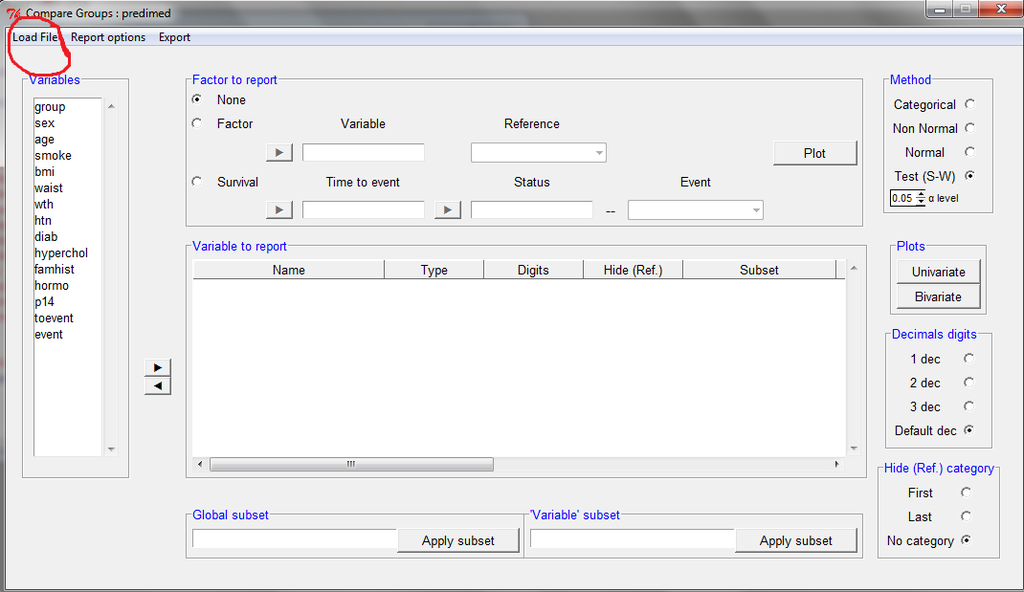

- **Step 2.** Choose the variables to be described (row-variables).

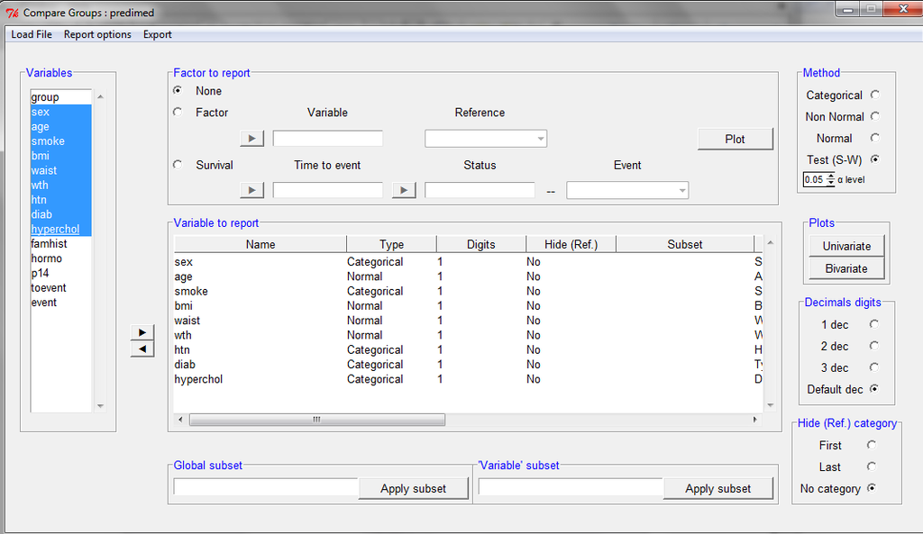

- **Step 3.** If descriptives by group are desired (for example), move the variable *group* to the GUI top frame, making it the factor variable. To report descriptives for the whole sample (i.e., no groups), click on the “none” button.

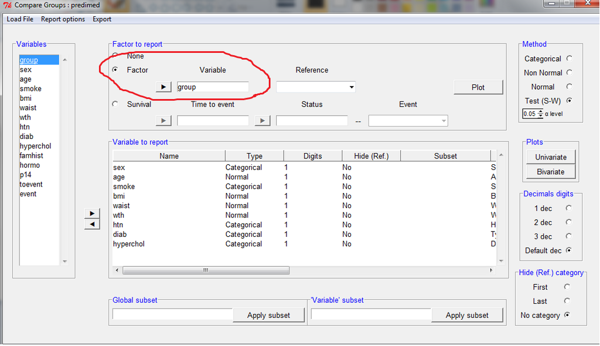

- **Step 4.** It is possible to hide the first, last or no categories of a categorical row-variable. In this example, “Male” levels will be hidden for Sex; conversely, all categories will be shown for other categorical variables.

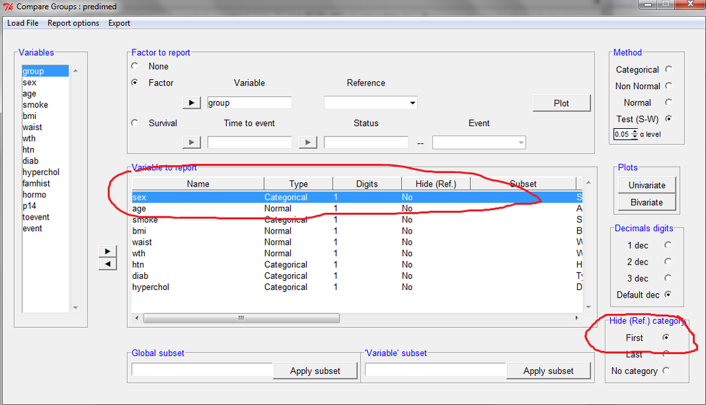

- **Step 5.** For each continuous variable, it is possible to specify whether to treat it as normal or non-normal or to transform a numerical variable into a categorical one. This last option can be interesting if a categorical variable has been coded as numerical. By default, all continuous variables are treated as normal. In this example, Waist circumference will be treated as non-normal, i.e., median and quartiles will be reported instead of mean and standard deviation.

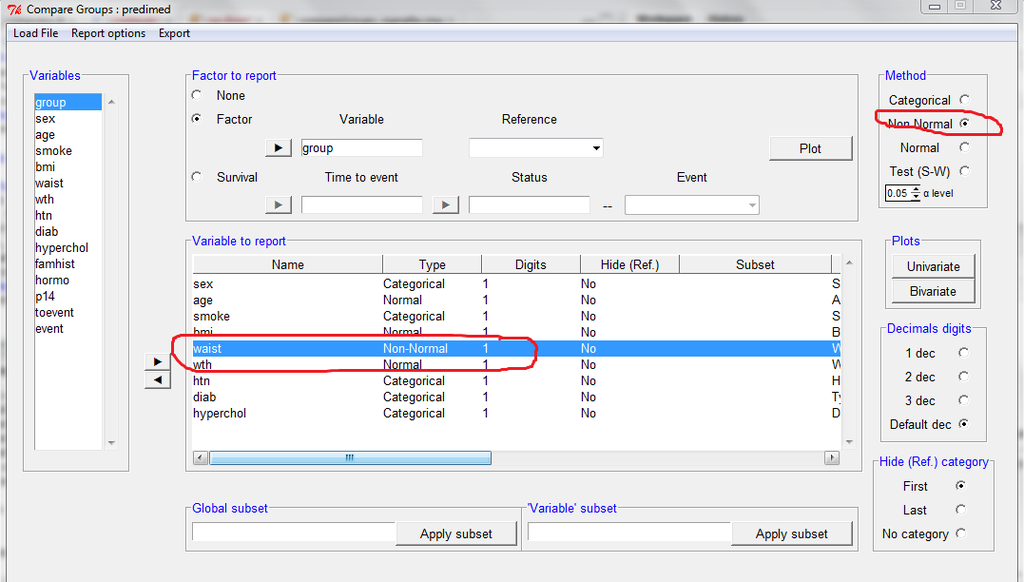

- **Step 6.** For each row-variable, it is possible to select a subset of individuals from the data set to be included. In this example, descriptives of Body mass index, Waist circumference and Waist-to-height ratio will be reported only for Female participants. Also, it is possible to specify criteria to select a subset of individuals to be included for all row-variables: type the logical condition (selection criteria of individuals) on the “Global subset” window instead of “Variable subset”.

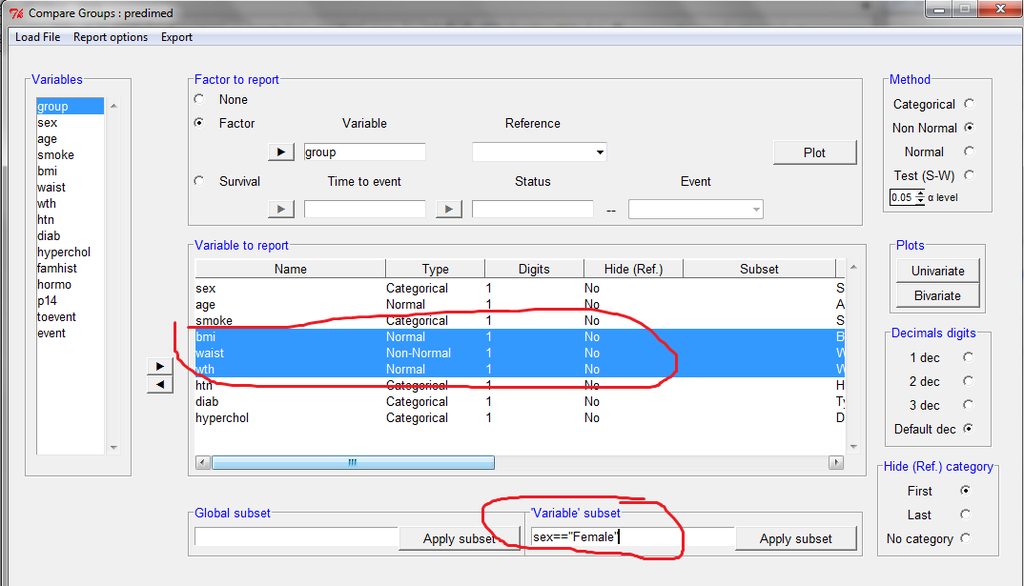

- **Step 7.** Some bivariate table characteristics can be set by clicking on “Report options” from the main menu, such as to report descriptives (mean, frequencies, medians, etc.), display the p-trend, and show only relative frequencies.

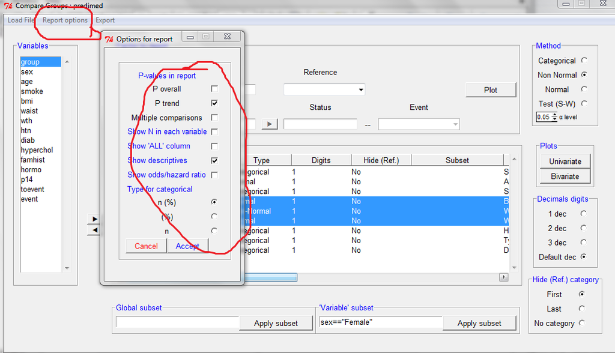

- **Step 8.** Finally, specify the bivariate table format (LaTeX, CVS plain text or HTML). Clicking on “print”" will then display the bivariate table, as well as a summary (available data, etc.), on the **`R`** console. The table can also be exported to the file formats listed.

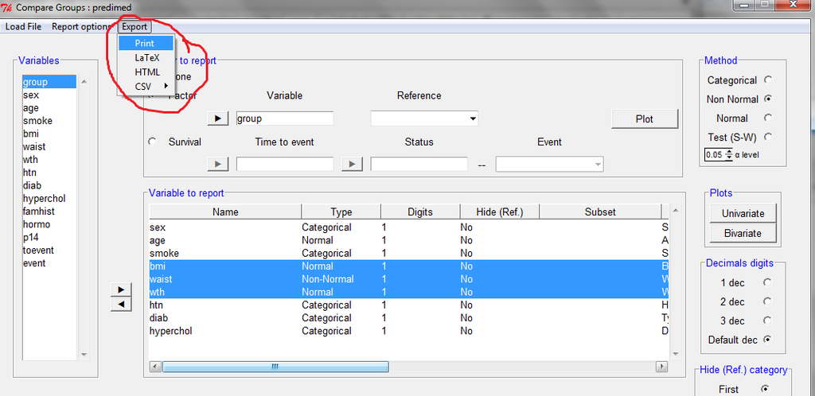

## 5.1 Computing Odds Ratio

For a case-control study, it may be necessary to report the Odds Ratio between cases and controls for each variable. The table below contains Odds Ratios for each row-variable by hypertension status.

Summary descriptives table by groups of `Hypertension’

|  | OR | p.ratio | p.overall |
| --- | --- | --- | --- |
| Age | 1.04 [1.03;1.05] | <0.001 | <0.001 |
| Sex: Female | 1.82 [1.60;2.08] | 0.000 | <0.001 |
| Smoking: |  |  | <0.001 |
| Never | Ref. | Ref. |  |
| Current | 0.43 [0.36;0.51] | 0.000 |  |
| Former | 0.63 [0.54;0.73] | <0.001 |  |
| Body mass index | 1.10 [1.08;1.12] | <0.001 | <0.001 |
| Waist circumference | 1.01 [1.01;1.02] | <0.001 | <0.001 |
| Waist-to-height ratio | 71.5 [25.6;199] | <0.001 | <0.001 |
| Type-2 diabetes | 0.25 [0.22;0.29] | 0.000 | <0.001 |
| Dyslipidemia | 1.75 [1.53;2.01] | <0.001 | <0.001 |
| Family history of premature CHD | 0.87 [0.75;1.01] | 0.070 | 0.074 |
| Hormone-replacement therapy | 1.08 [0.64;1.97] | 0.773 | 0.856 |
| MeDiet Adherence score | 0.96 [0.93;1.00] | 0.028 | 0.029 |
| follow-up to main event (years) | 0.94 [0.90;0.98] | 0.002 | 0.001 |
| AMI, stroke, or CV Death | 1.04 [0.75;1.48] | 0.826 | 0.879 |

To build this table, as illustrated in the screens below, you would select *htn* variable (Hypertension status) as the factor variable, indicate “no” category on the “reference” pull-down menu, and mark “Show odds/hazard ratio” in the “Report Options” menu before exporting the table.

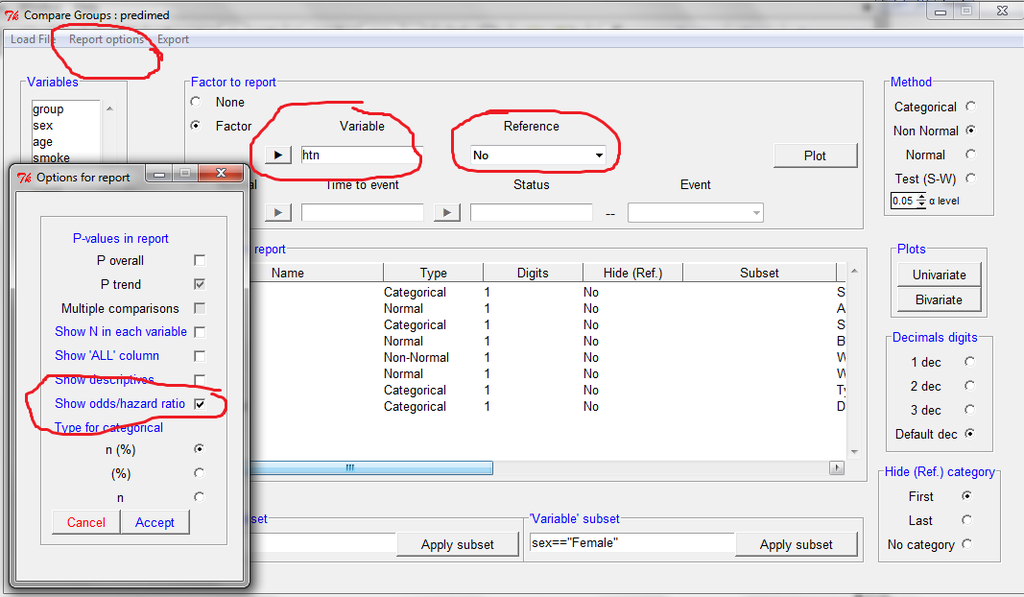

## 5.2 Computing Hazard Ratio

In a cohort study, it may be more informative to compute hazard ratio taking into account time-to-event.

Summary descriptives table by groups of `AMI, stroke, or CV Death’

|  | No event | Event | HR | p.ratio | p.overall |
| --- | --- | --- | --- | --- | --- |
|  | N=6072 | N=252 |  |  |  |
| Intervention group: |  |  |  |  | 0.011 |
| Control | 1945 (32.0%) | 97 (38.5%) | Ref. | Ref. |  |
| MedDiet + Nuts | 2030 (33.4%) | 70 (27.8%) | 0.66 [0.48;0.89] | 0.008 |  |
| MedDiet + VOO | 2097 (34.5%) | 85 (33.7%) | 0.70 [0.53;0.94] | 0.018 |  |
| Age | 66.9 (6.14) | 69.4 (6.65) | 1.06 [1.04;1.09] | <0.001 | <0.001 |
| Sex: |  |  |  |  | <0.001 |
| Male | 2528 (41.6%) | 151 (59.9%) | Ref. | Ref. |  |
| Female | 3544 (58.4%) | 101 (40.1%) | 0.49 [0.38;0.63] | <0.001 |  |

To generate this table, select *toevent* variable and *event*, indicating the time-to-event and the status, respectively, and select the event category for the status variable. Finally, as for Odds Ratios, mark ‘Show odds/hazard ratio’ in the ‘Report Options’ menu before exporting the table.

[figure not shown]

To return to the **`R`** console, just close the GUI window.

# 6 Using Web User Inferface (WUI) - Shiny

Since version 2.1, **`compareGropus`** package incorporates a **Web User Interface (WUI)** based on **`shiny`** **`R`** available on CRAN repository (RStudio and Inc. 2014) [shiny website](http://shiny.rstudio.com) to facilitate the use of the package for non **`R`** users.

This application includes almost all the options existing in “type on” version. Also, thanks to the power of **`shiny`** package, the user can see the results when setting the included variable, the groups, number of decimals, etc almost instantaneously (“reactivity” -see **`shiny`** manual and examples-). This is very useful to modify and customize the descriptive table before saving it in the desired format saving a lot of time.

In the following subsections, we list and describe all the options available in the **`Shiny-compareGroups`** application, and we illustrate how it works with a real example.

## 6.1 Menus and options

Once the WUI is called, a web browser is launched with two main parts: in the left hand side there are all the control menu options to read the data frame from different format files, select the variables list to be analysed, specify the number of digits of the descriptives or p-values displayed in the bivariate table, and much more other aspects; while the right hand side contains the results, i.e, a table containing a basic summary of all variables, the bivariate table or some plots.

Following, an exhaustive list describing all the options are presented:

### 6.1.1 Control menu (left side)

#### 6.1.1.1 START

A panel with all the options to select the data base and to select the analysed variables. Different file formats are allowed; in the present version these are: SPSS, plain text (txt or csv), EXCEL (2000 or 2007) or **`R`** (.rda or RData). Also, it is possible to select example data already present in the **`compareGroups`** package (REGICOR and PREDIMED) and SNPS from **`SNPassoc`** package.

#### 6.1.1.2 SETTINGS

A panel with different issues to control for different aspects of the bivariate table:

- Type Each variable can be analysed as normal or non-normal or as categorical. In the first case, mean and standard deviation are displayed; for the second case, medians and quantiles; and for the latest, frequencies and proportions.
- Response Control menu to select which variable indicates the group. Three choices are possible:
  1. **None:** descriptives are performed for the entire data set with no groups.
     2. **Group:** a variable must be selected. By default, only factor variables with five or less categories can be selected. The descriptives will be performed by these groups. When the grouping variable has only 2 categories, Odds Ratio (OR) can be computed.
     3. **Survival:** to perform survival analysis where the response is a right censored variable,i.e., with time variable and a variable indicating the censoring (i.e., whether or not the individual suffered the disease). Also, the disease or case status must be indicated.
- Hide For categorical variables, select the category you want to be hidden. Additionally, in the “hide no” input text windows you can type the category which represents “no” in the sense that the category named as indicated for all binary variables are hidden.
- Subset A global subset can be typed affecting all analysed variables. Also you can select a subgroup of individuals for each variable. In any case, a logical expression in **`R`** language must be typed:

  ```
  | Operator | **R**   |
  |:--------:|:-------:|
  |=         | `==`    |
  |or        | `|`     |
  |and       | `&`     |
  |not       | `!`     |
  ```

> > Note that to indicate the category, you must type the number that appears in the “VALUES” table on right side of the application instead of its >>name. For example, for gender, type 1 instead of “male” and 2 instead of “female”, if “male” is the first category and “female” is the second.
- OR/HR Options for Odds Ratio (OR) when response is binary or Hazard Ratios (HR) for right censored response. You can specify the reference category when computing the OR or HR for the categorical variables. For continuous variables, the scale can be changed. This is very useful for variables with a wide range such as total cholesterol, where it makes more sense to display the OR/HR for each 10 units of change rather than a single unit.

#### 6.1.1.3 DISPLAY

In this panel, the user can select which information must be displayed in the resulting bivariate table, and in which format, etc.

- Show What to be displayed in the bivariate table:
  - **ALL:** Descriptives for the entire data set.
  - **p-overall:** p-value comparing the means, medians, proportions or incidence among groups.
  - **Descriptives:** Descriptives (means, medians, proportions, etc.) by groups.
  - **p-trend:** p-value for trend. It is supposed that the groups are ordered.
  - **OR/HR:** Odds Ratio or Hazard Ratio for binary or time-to-event response (grouping variable), respectively.
  - **Available:** Number of individuals with valid data for each variable and each groups.
  - **NA category:** For categorical variables, the non-available data is considered as a new category.
  - **Pairwise p-value:** When more than two groups are considered, p-values corresponding to 2 by 2 comparisons are performed taking into account multiple testing.
  - **Simplify:** Empty categories (with no available data) are removed from the analyses.
- Format The user can specify how to display the mean and standard deviation, the quantiles and frequencies.
- Decimals The number of decimals to be displayed in the bivariate table, for descriptives, p-values and for OR / HR.
- Labels This tab allows to change the “key” headers of the descriptive table such as “ALL”, “p-value”, etc.

#### 6.1.1.4 SAVE

A panel with the options to save the bivariate table in different formats: PDF, CSV, TXT, HTML, Word (.docx) or Excel (.xlsx).

If PDF format is selected, size can be specified as well as landscape format. These options may be useful when the table is big or contains lots of columns.

### 6.1.2 Results panels (right side)}

- ABOUT: Explanation about both the **`compareGroups`** **`R`**-package and its Web User Interface (WUI) version. Also, it contains the security rules of the data sent by the user when using WUI remotely (from [**`compareGroups`** website](http://www.comparegroups.eu/)).
- VALUES Using this tab, the user can take a look at the data contained in the data set.
  - **Summary:** A table with the the name, label and a basic summary of all the variables contained in the data set.
  - **Values:** A table with the raw values in the data set. By default only the first ten rows are displayed, but the user can set the number of rows to be shown and navigate through the data set.
- TABLE The bivariate table contaning the descriptives, p-values, etc. for the selected variables. Additionaly, pressing “info” button it is displayed the “info table” containing, for each descripted variable, how many observations are available for each group, whether it is treated as normal, non-normal or categorical, which criteria, if any, has been used to select a subset of individuals and if, the Odds Ratio or Hazard Ratio is computed, the factor for which the variable has been multiplied.
- PLOT Univariate or bivariate (taking into account the groups if proceeds) plots of selected variable.
- SNPs Descriptives of SNPs (Single Nucleotide Polymorphims) with appropriate statistics and tests for these genetic variants. To perform this analysis, only SNPs variables can be selected. A factor response to display genotype frequencies by groups is permitted but not a time-to-event response variable.

## 6.2 Example

In this section we illustrate how to analyse a data set.

### 6.2.1 Launch the WUI application

To use the WUI locally (and not on a remote server), first load the **`compareGroups`** package and call the `cGroupsWUI` function:

```r
library(compareGroups)
cGroupsWUI()
```

### 6.2.2 Load the data

In this example we will load the PREDIMED data set from the PREDIMED study (Estruch et al. 2013). This data is already available in the **`compareGroups`** package.

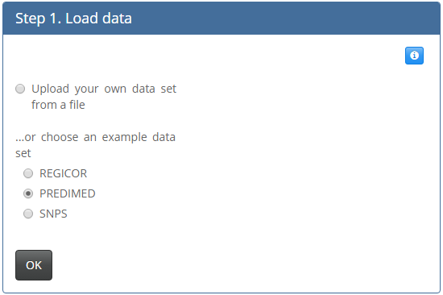

### 6.2.3 Select the variables to be analysed

After the data is loaded satisfactory, the “Step 2. Select variable” panel is opened automatically. Using this panel, we will select all variables except the “event” and “toevent” (the time-to-event) variables. They will represent the response and must be removed from the row-variables.

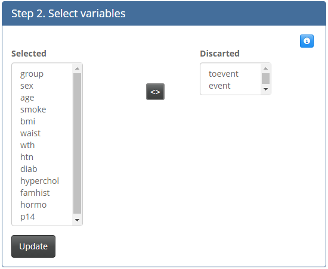

### 6.2.4 Select the grouping variable

Since PREDIMED is a longitudinal study where the main goal is to check whether the mediterranean diet is related to a less incidence of cardiovascular disease, we will take the response as the time to cardiovascular event. To do so, we will select “Survival” response type, setting the “toevent” as time variable and “event” as indicator variable (taking “yes” as case code).

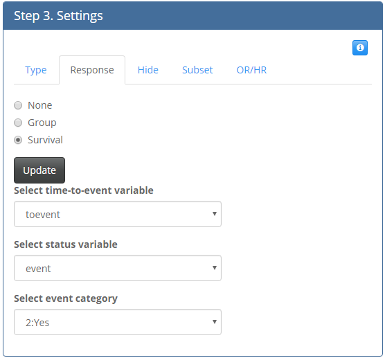

### 6.2.5 Take a look at the plots

To see which continuous variables should be treated as normal and which not. By default, **`compareGroups`** performs a Shapiro-Wilks normality test to decide which variables are normal. But we may want to check the normality assumption graphically.

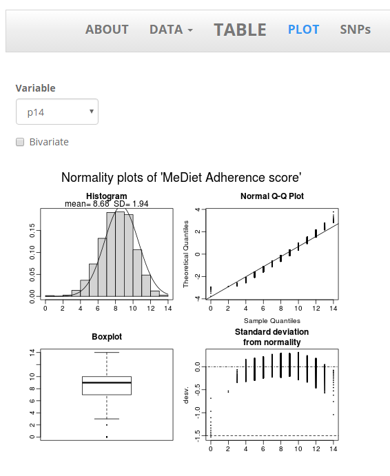

### 6.2.6 Set the options.

- **Type:** Specify the variables to be treated as normal and the ones as non normal. To specify that all of them will be treated as normal, except `p14’ for which median and quartiles are displayed instead of mean and SD:

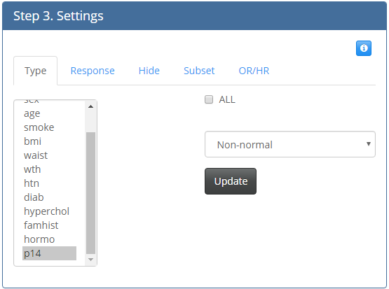

- **Hide:** To hide the “No” category for binary variables such as hypertension, diabetes, etc., we will type “No” in the “hide no” input text window. Also, to hide the “female” category for we will select the “sex” variable and “female” category and press “Update” button afterwards.

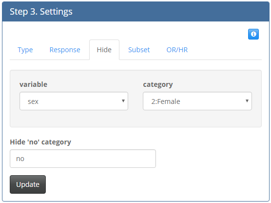

- **OR:** Since we have hidden the females, we have to do the same for the HR. Also, for the waist we will change the scale to 5. Doing this, the HR will represent the change in 5 units.

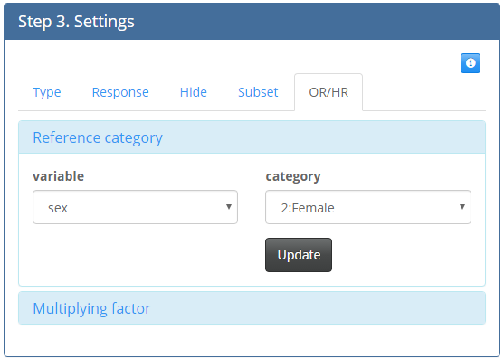

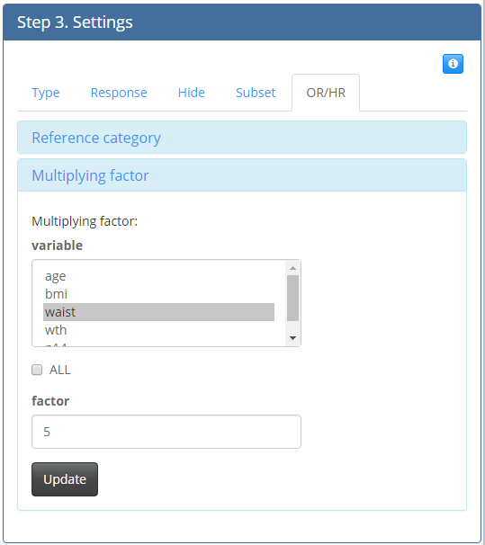

- **Subset:** If we want to do the analysis only for male type “sex==1” or “sex==2” in only females must be analysed in the “global subset” text input window.

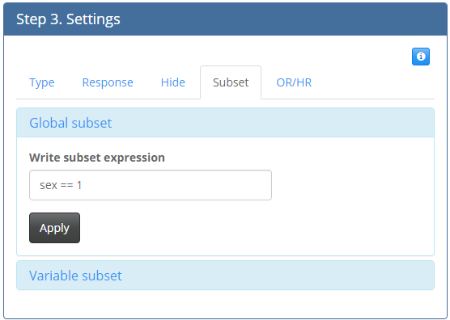